# FFT_SSVEP_analysis

Christopher

2 7 2024

Modelling of raw [*CSD based*] amplitude values from fft-based data via linear mixed models via standard anova models

```r
rm(list=ls()) # clear environment
library(lme4)
library(readxl)
library(tidyverse)
library(data.table)
library(tidyverse)
library(afex)
library(broom)
library(apa)
library(kableExtra)
library(lmerTest)
library(pbkrtest)
library(effects)
library(visreg)
library(sjPlot)
library(broom.mixed)
library(pander)
library(mediation)
library(multcomp)
library(multcompView)
library(magrittr)
library(multipanelfigure)
library(ggbeeswarm)
library(lsmeans)
library(BayesFactor)
library(ggpubr)
library(gpairs)
library(DescTools)
library(cowplot)
library(ggpol)
library(logspline)

library(brms)

library(bayestestR)

library(rstatix)
library(ggtern)

source('C:/Dropboxdata/Dropbox/work/R-statistics/general_functions/RainCloudPlots/tutorial_R/R_rainclouds.R')
source('C:/Dropboxdata/Dropbox/work/R-statistics/general_functions/RainCloudPlots/tutorial_R/R_rainclouds.R')

source('C:/Dropboxdata/Dropbox/work/R-statistics/examples/Bayesian_rank-based_hypothesis_testing/rankBasedCommonFunctions.R')
source('C:/Dropboxdata/Dropbox/work/R-statistics/examples/Bayesian_rank-based_hypothesis_testing/rankSumSampler.R') # Wilcoxon rank sum function
source('C:/Dropboxdata/Dropbox/work/R-statistics/examples/Bayesian_rank-based_hypothesis_testing/signRankSampler.R') # Wilcoxon signed-rank function
source('C:/Dropboxdata/Dropbox/work/R-statistics/examples/Bayesian_rank-based_hypothesis_testing/spearmanSampler.R')# Spearman's rho function




# broad cluster
# CSD based normalized to pre-cue baseline in %
#
DATAPath = "data_in/FFT_Amp_data_largeclust_06-14-2024_13-19.csv"
t_baseline = c(-1000, 0)


# broad cluster | smaller central cluster
# CSD based normalized to pre-cue baseline in %
#
# DATAPath = "data_in/FFT_Amp_data_largeclust_06-24-2024_15-43.csv"
# t_baseline = c(-1000, 0)


# broad cluster | smaller central cluster
# CSD based normalized to pre-cue baseline in %
# for changed experiment starting with participant 22: isoluminant stimuli and lower flicker frequencies
#
DATAPath = "data_in/FFT_Amp_data_largeclust_allsubs_08-30-2024_11-21.csv"
t_baseline = c(-1000, 0)


# broad cluster | larger central cluster |
# peri: not correct!
# CSD based normalized to pre-cue baseline in %
# for changed experiment starting with participant 22: isoluminant stimuli and lower flicker frequencies
#
# DATAPath = "data_in/FFT_Amp_data_pericenter_allsubs_07-02-2024_11-46.csv"
# t_baseline = c(-1000, 0)
#
# broad cluster | very broad central cluster
# CSD based normalized to pre-cue baseline in %
# for changed experiment starting with participant 22: isoluminant stimuli and lower flicker frequencies
# #
# DATAPath = "data_in/FFT_Amp_data_largecenterclust_allsubs_09-11-2024_14-45.csv"
# t_baseline = c(-1000, 0)



#!!!!!!! relevant
# broad cluster | larger central cluster as in Tango study | peri both clusters but smaller
# CSD based normalized to pre-cue baseline in %
# for changed experiment starting with participant 22: isoluminant stimuli and lower flicker frequencies
DATAPath = "data_in/FFT_Amp_data_CenterTangoStudyPeriSmall_05-23-2025_11-56.csv"
t_baseline = c(-1000, 0)

# broad cluster | larger central cluster as in Tango study | peri only center
# DATAPath = "data_in/FFT_Amp_data_TangoStudyPeriOnlyCenter_11-25-2024_14-17.csv"
# t_baseline = c(-1000, 0)

# # broad cluster | larger central cluster as in Tango study | peri only lateral | in this study shows gain for attended
# DATAPath = "data_in/FFT_Amp_data_TangoStudyPeriOnlyLateral_11-25-2024_14-17.csv"
# t_baseline = c(-1000, 0)


#!!!!!!!


# replication relevant
# broad cluster | larger central cluster as in Tango study | peri both clusters as in Tango study
# CSD based normalized to pre-cue baseline in %
# for changed experiment starting with participant 22: isoluminant stimuli and lower flicker frequencies
# DATAPath = "data_in/FFT_Amp_data_TangoStudy_05-23-2025_11-53.csv"
# t_baseline = c(-1000, 0)




options(scipen=1, digits=7)
```

## Prepare data

1. Read in data:
- data_in/FFT_Amp_data_CenterTangoStudyPeriSmall_05-23-2025_11-56.csv
- with pre-cue [-1000, 0] ms

```r
sub_sample = c(0)
# sub_sample = as.factor(c(26,30, 31,37, 38)) # no ssvep people discarded
sub_sample = as.factor(c(42)) # low trial number


# read in data
DataIn <- read.csv(DATAPath, sep = ";") %>%
  mutate(subjects = as.factor(subjects))%>%
  filter(!subjects %in% sub_sample)
head(DataIn)
str(DataIn)
```

## Illustrate SSVEP Data

### 1a Illustrate Data as is | center RDKs

plot differently

```r
#evoked raw#### for center

# set overall limits?
dat2plot <- DataIn %>%
  filter(RDK_position2=="center") %>%
  group_by(subjects, time, RDK_isattended, RDK_colorlum)%>%
  summarise(amplitude_evoked=mean(amplitude_evoked), modulation_evoked=mean(modulation_evoked))%>%
  filter(time=='[0.5 1.5] ')
```

```
## can override using the `.groups` argument.
```

```r
# set limits
yax_limits <- c( min(dat2plot$modulation_evoked), max(dat2plot$modulation_evoked))
yax_limits <- round(yax_limits + c(-1, 1)*diff(yax_limits)*0.1)
yax_limits <- yax_limits + c(-1, 1)*diff(yax_limits)*0.1


dat2plot <- DataIn %>%
  filter(RDK_position2=="center") %>%
  group_by(subjects, time, RDK_isattended, RDK_colorlum)%>%
  summarise(amplitude_evoked=mean(amplitude_evoked), modulation_evoked=mean(modulation_evoked))%>%
  filter(time=='[0.5 1.5] ', RDK_colorlum == 'offset_to_bckgrd')
```

```
## can override using the `.groups` argument.
```

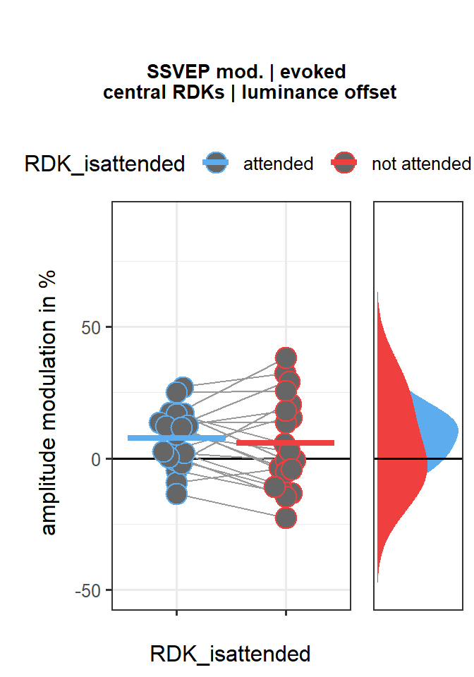

```r
# set limits
# yax_limits <- c( min(dat2plot$modulation_evoked), max(dat2plot$modulation_evoked))
# yax_limits <- round(yax_limits + c(-1, 1)*diff(yax_limits)*0.1)
# yax_limits <- yax_limits + c(-1, 1)*diff(yax_limits)*0.2
# # yax_limits <- c(-27, 15)

theme_set(theme_bw())
plot1 <- ggplot(dat2plot, aes(x = RDK_isattended, y = modulation_evoked, fill = RDK_isattended)) +
  geom_hline(yintercept=0, show.legend = FALSE) +
  geom_line(aes(group = interaction(subjects,time)),colour = "grey60",alpha = 1,size =0.5) +
  geom_beeswarm(aes(color = RDK_isattended, x = RDK_isattended,
                    group = RDK_isattended), cex=3, size = 5,alpha=1,fill="grey40",shape=21)+
  # geom_point(aes(color = RDK_isattended, x = interaction(time,RDK_isattended),
  #                   group = RDK_isattended), size = 4,alpha=0.4)+
  stat_summary(fun.y=mean, aes(ymin=..y.., ymax=..y.., color =RDK_isattended), geom='errorbar', width=0.9, size=1.5) +
  scale_x_discrete("RDK_isattended", breaks=waiver(), labels = rep(c(""),1,2)) +
  # theme(legend.position="bottom") +
  ylab(expression(paste("amplitude modulation in %")))+
  scale_fill_manual(values=c("steelblue2", "#F03F3F"))+
  scale_color_manual(values=c("steelblue2", "#F03F3F"))+
  #  scale_fill_manual(values=c("#193A3D", "#F03F3F"))+
  # scale_color_manual(values=c("#193A3D", "#F03F3F"))+
  # scale_fill_manual(values=c(rgb2hex(0.0, 153.0, 204.0),rgb2hex(0.0, 77, 102.0)))+
  # scale_color_manual(values=c(rgb2hex(0.0, 153.0, 204.0),rgb2hex(0.0, 77, 102.0)))+
  theme(legend.position="none")+
  # scale_y_continuous(limits=c(-60, 140))
  scale_y_continuous(limits=yax_limits)


plot2 <- ggplot(dat2plot, aes(y = modulation_evoked, fill = RDK_isattended, x = 1)) +
  geom_flat_violin(aes(fill = RDK_isattended),position = position_nudge(x = .1, y = 0),
                   adjust = 1.3, trim = FALSE, alpha = 1, colour = NA)+
  geom_hline(yintercept=0, show.legend = FALSE) +
  # scale_fill_manual(values=c("#193A3D", "#F03F3F"))+
  # scale_color_manual(values=c("#193A3D", "#F03F3F"))+
  scale_fill_manual(values=c("steelblue2", "#F03F3F"))+
  scale_color_manual(values=c("steelblue2", "#F03F3F"))+
  # scale_fill_manual(values=c(rgb2hex(0.0, 153.0, 204.0),rgb2hex(0.0, 77, 102.0)))+
  # scale_color_manual(values=c(rgb2hex(0.0, 153.0, 204.0),rgb2hex(0.0, 77, 102.0)))+
  theme(axis.title.y=element_blank(),
        axis.text.y=element_blank(),
        axis.ticks.y=element_blank())+
  theme(axis.title.x=element_blank(),
        axis.text.x=element_blank(),
        axis.ticks.x=element_blank())+
  theme(panel.grid.major = element_blank(), panel.grid.minor = element_blank())+
  # scale_y_continuous(limits=c(-60, 140))
  scale_y_continuous(limits=yax_limits)



# cowplot::plot_grid(plot1, plot2, plot3, ncol = 3,labels = "AUTO")
plotttitle <- ggdraw() +
  draw_label("SSVEP mod. | evoked \ncentral RDKs | luminance offset", fontface='bold', size = 10)
plotplots <- ggarrange(plot1, plot2,ncol = 2,common.legend = TRUE,align = "h", widths=c(3,1))

savefig <- multi_panel_figure(columns = 1, rows = 1, panel_label_type = "none", width = 3.5, height = 5, unit = "in")
saveplot <- ggarrange(plotttitle, plotplots, nrow = 2, heights=c(0.2, 1))

savefig %<>%
  fill_panel(saveplot, column = 1, row = 1)
savefig
```

```r
# save_multi_panel_figure(savefig, "figures/FFT_BeeSwarm_Mod_ALPHA_COL_34subs.eps")




dat2plot <- DataIn %>%
  filter(RDK_position2=="center") %>%
  group_by(subjects, time, RDK_isattended, RDK_colorlum)%>%
  summarise(amplitude_evoked=mean(amplitude_evoked), modulation_evoked=mean(modulation_evoked))%>%
  filter(time=='[0.5 1.5] ', RDK_colorlum == 'isolum__to_bckgrd')
```

```
## can override using the `.groups` argument.
```

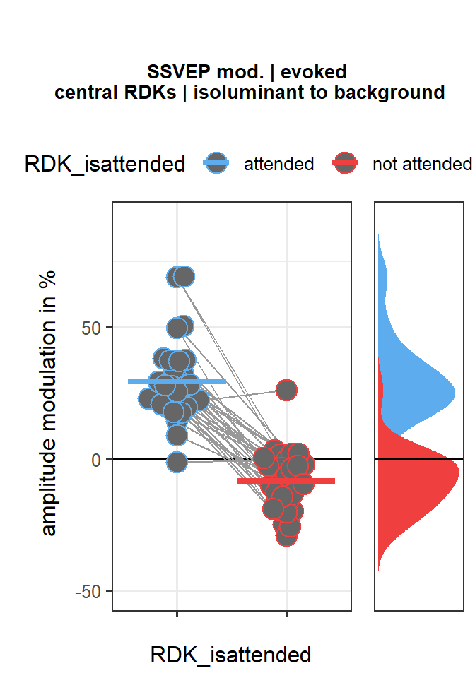

```r
# set limits
# yax_limits <- c( min(dat2plot$modulation_evoked), max(dat2plot$modulation_evoked))
# yax_limits <- round(yax_limits + c(-1, 1)*diff(yax_limits)*0.1)
# yax_limits <- yax_limits + c(-1, 1)*diff(yax_limits)*0.2
# # yax_limits <- c(-27, 15)

theme_set(theme_bw())
plot1 <- ggplot(dat2plot, aes(x = RDK_isattended, y = modulation_evoked, fill = RDK_isattended)) +
  geom_hline(yintercept=0, show.legend = FALSE) +
  geom_line(aes(group = interaction(subjects,time)),colour = "grey60",alpha = 1,size =0.5) +
  geom_beeswarm(aes(color = RDK_isattended, x = RDK_isattended,
                    group = RDK_isattended), cex=3, size = 5,alpha=1,fill="grey40",shape=21)+
  # geom_point(aes(color = RDK_isattended, x = interaction(time,RDK_isattended),
  #                   group = RDK_isattended), size = 4,alpha=0.4)+
  stat_summary(fun.y=mean, aes(ymin=..y.., ymax=..y.., color =RDK_isattended), geom='errorbar', width=0.9, size=1.5) +
  scale_x_discrete("RDK_isattended", breaks=waiver(), labels = rep(c(""),1,2)) +
  # theme(legend.position="bottom") +
  ylab(expression(paste("amplitude modulation in %")))+
  scale_fill_manual(values=c("steelblue2", "#F03F3F"))+
  scale_color_manual(values=c("steelblue2", "#F03F3F"))+
  #  scale_fill_manual(values=c("#193A3D", "#F03F3F"))+
  # scale_color_manual(values=c("#193A3D", "#F03F3F"))+
  # scale_fill_manual(values=c(rgb2hex(0.0, 153.0, 204.0),rgb2hex(0.0, 77, 102.0)))+
  # scale_color_manual(values=c(rgb2hex(0.0, 153.0, 204.0),rgb2hex(0.0, 77, 102.0)))+
  theme(legend.position="none")+
  # scale_y_continuous(limits=c(-60, 140))
  scale_y_continuous(limits=yax_limits)


plot2 <- ggplot(dat2plot, aes(y = modulation_evoked, fill = RDK_isattended, x = 1)) +
  geom_flat_violin(aes(fill = RDK_isattended),position = position_nudge(x = .1, y = 0),
                   adjust = 1.3, trim = FALSE, alpha = 1, colour = NA)+
  geom_hline(yintercept=0, show.legend = FALSE) +
  # scale_fill_manual(values=c("#193A3D", "#F03F3F"))+
  # scale_color_manual(values=c("#193A3D", "#F03F3F"))+
  scale_fill_manual(values=c("steelblue2", "#F03F3F"))+
  scale_color_manual(values=c("steelblue2", "#F03F3F"))+
  # scale_fill_manual(values=c(rgb2hex(0.0, 153.0, 204.0),rgb2hex(0.0, 77, 102.0)))+
  # scale_color_manual(values=c(rgb2hex(0.0, 153.0, 204.0),rgb2hex(0.0, 77, 102.0)))+
  theme(axis.title.y=element_blank(),
        axis.text.y=element_blank(),
        axis.ticks.y=element_blank())+
  theme(axis.title.x=element_blank(),
        axis.text.x=element_blank(),
        axis.ticks.x=element_blank())+
  theme(panel.grid.major = element_blank(), panel.grid.minor = element_blank())+
  # scale_y_continuous(limits=c(-60, 140))
  scale_y_continuous(limits=yax_limits)



# cowplot::plot_grid(plot1, plot2, plot3, ncol = 3,labels = "AUTO")
plotttitle <- ggdraw() +
  draw_label("SSVEP mod. | evoked \ncentral RDKs | isoluminant to background", fontface='bold', size = 10)
plotplots <- ggarrange(plot1, plot2,ncol = 2,common.legend = TRUE,align = "h", widths=c(3,1))

savefig <- multi_panel_figure(columns = 1, rows = 1, panel_label_type = "none", width = 3.5, height = 5, unit = "in")
saveplot <- ggarrange(plotttitle, plotplots, nrow = 2, heights=c(0.2, 1))

savefig %<>%
  fill_panel(saveplot, column = 1, row = 1)
savefig
```

```r
# save_multi_panel_figure(savefig, "figures/FFT_BeeSwarm_Mod_ALPHA_COL_34subs.eps")
```

### 2a Illustrate Data as is | both subsets | general pre-to-post-cue modulation

plot differently

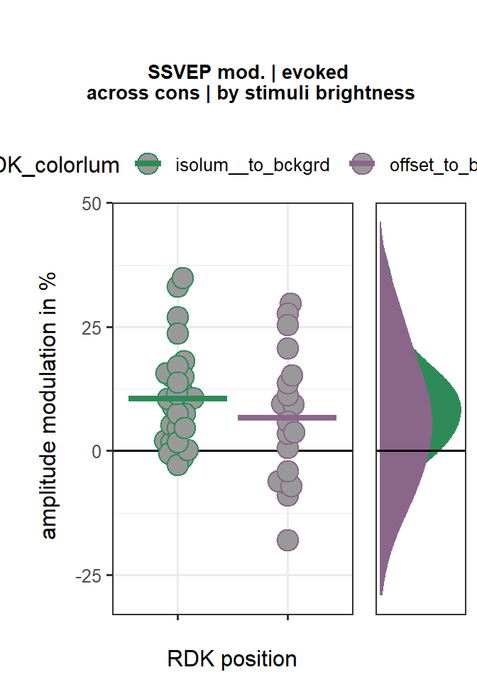

```r
#evoked raw#### for center

# set overall limits?
dat2plot <- DataIn %>%
  filter(RDK_ispresented=="presented", RDK_position1=="center")%>%
  group_by(subjects, time, RDK_colorlum)%>%
  summarise(amplitude_evoked=mean(amplitude_evoked), modulation_evoked=mean(modulation_evoked))%>%
  filter(time == '[0.5 1.5] ')
# set limits
yax_limits <- c( min(dat2plot$modulation_evoked), max(dat2plot$modulation_evoked))
yax_limits <- round(yax_limits + c(-1, 1)*diff(yax_limits)*0.1)
yax_limits <- yax_limits + c(-1, 1)*diff(yax_limits)*0.1




theme_set(theme_bw())
plot1 <- ggplot(dat2plot, aes(x = RDK_colorlum, y = modulation_evoked, fill = RDK_colorlum)) +
  geom_hline(yintercept=0, show.legend = FALSE) +
  # geom_line(aes(group = interaction(subjects,time)),colour = "grey60",alpha = 1,size =0.5) +
  geom_beeswarm(aes(color = RDK_colorlum, x = RDK_colorlum,
                    group = RDK_colorlum), cex=3, size = 5,alpha=1,fill="grey60",shape=21)+
  # geom_point(aes(color = RDK_isattended, x = interaction(time,RDK_isattended),
  #                   group = RDK_isattended), size = 4,alpha=0.4)+
  stat_summary(fun.y=mean, aes(ymin=..y.., ymax=..y.., color =RDK_colorlum), geom='errorbar', width=0.9, size=1.5) +
  scale_x_discrete("RDK position", breaks=waiver(), labels = rep(c(""),1,2)) +
  # theme(legend.position="bottom") +
  ylab(expression(paste("amplitude modulation in %")))+
  scale_fill_manual(values=c("seagreen", "plum4"))+
  scale_color_manual(values=c("seagreen", "plum4"))+
  #  scale_fill_manual(values=c("#193A3D", "#F03F3F"))+
  # scale_color_manual(values=c("#193A3D", "#F03F3F"))+
  # scale_fill_manual(values=c(rgb2hex(0.0, 153.0, 204.0),rgb2hex(0.0, 77, 102.0)))+
  # scale_color_manual(values=c(rgb2hex(0.0, 153.0, 204.0),rgb2hex(0.0, 77, 102.0)))+
  theme(legend.position="none")+
  # scale_y_continuous(limits=c(-60, 140))
  scale_y_continuous(limits=yax_limits)


plot2 <- ggplot(dat2plot, aes(y = modulation_evoked, fill = RDK_colorlum, x = 1)) +
  geom_flat_violin(aes(fill = RDK_colorlum),position = position_nudge(x = .1, y = 0),
                   adjust = 1.3, trim = FALSE, alpha = 1, colour = NA)+
  geom_hline(yintercept=0, show.legend = FALSE) +
  # scale_fill_manual(values=c("#193A3D", "#F03F3F"))+
  # scale_color_manual(values=c("#193A3D", "#F03F3F"))+
  scale_fill_manual(values=c("seagreen", "plum4"))+
  scale_color_manual(values=c("seagreen", "plum4"))+
  # scale_fill_manual(values=c(rgb2hex(0.0, 153.0, 204.0),rgb2hex(0.0, 77, 102.0)))+
  # scale_color_manual(values=c(rgb2hex(0.0, 153.0, 204.0),rgb2hex(0.0, 77, 102.0)))+
  theme(axis.title.y=element_blank(),
        axis.text.y=element_blank(),
        axis.ticks.y=element_blank())+
  theme(axis.title.x=element_blank(),
        axis.text.x=element_blank(),
        axis.ticks.x=element_blank())+
  theme(panel.grid.major = element_blank(), panel.grid.minor = element_blank())+
  # scale_y_continuous(limits=c(-60, 140))
  scale_y_continuous(limits=yax_limits)



# cowplot::plot_grid(plot1, plot2, plot3, ncol = 3,labels = "AUTO")
plotttitle <- ggdraw() +
  draw_label("SSVEP mod. | evoked \nacross cons | by stimuli brightness",
             fontface='bold', size = 10)
plotplots <- ggarrange(plot1, plot2,ncol = 2,common.legend = TRUE,align = "h", widths=c(3,1))

savefig <- multi_panel_figure(columns = 1, rows = 1, panel_label_type = "none", width = 3.5, height = 5, unit = "in")
saveplot <- ggarrange(plotttitle, plotplots, nrow = 2, heights=c(0.2, 1))

savefig %<>%
  fill_panel(saveplot, column = 1, row = 1)
savefig
```

```r
# save_multi_panel_figure(savefig, "figures/FFT_BeeSwarm_Mod_ALPHA_COL_34subs.eps")
```

### 2b Illustrate Data as is | both subsets | general pre-to-post-cue attentional selectivity

plot differently

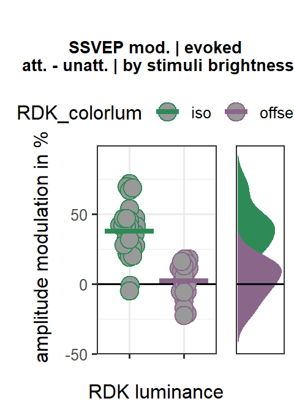

```r
#evoked raw#### for center

# set overall limits?
dat2plot <- DataIn %>%
  filter(RDK_ispresented=="presented", RDK_position1=="center")%>%
  group_by(subjects, time, RDK_colorlum,RDK_isattended)%>%
  summarise( modulation_evoked=mean(modulation_evoked))%>%
  filter(time == '[0.5 1.5] ')%>%
  pivot_wider(names_from = RDK_isattended, values_from = modulation_evoked) %>%
  mutate(modulation_evoked = attended - `not attended`)
# set limits
yax_limits <- c( min(dat2plot$modulation_evoked), max(dat2plot$modulation_evoked))
yax_limits <- round(yax_limits + c(-1, 1)*diff(yax_limits)*0.1)
yax_limits <- yax_limits + c(-1, 1)*diff(yax_limits)*0.1




theme_set(theme_bw())
plot1 <- ggplot(dat2plot, aes(x = RDK_colorlum, y = modulation_evoked, fill = RDK_colorlum)) +
  geom_hline(yintercept=0, show.legend = FALSE) +
  # geom_line(aes(group = interaction(subjects,time)),colour = "grey60",alpha = 1,size =0.5) +
  geom_beeswarm(aes(color = RDK_colorlum, x = RDK_colorlum,
                    group = RDK_colorlum), cex=3, size = 5,alpha=1,fill="grey60",shape=21)+
  # geom_point(aes(color = RDK_isattended, x = interaction(time,RDK_isattended),
  #                   group = RDK_isattended), size = 4,alpha=0.4)+
  stat_summary(fun.y=mean, aes(ymin=..y.., ymax=..y.., color =RDK_colorlum), geom='errorbar', width=0.9, size=1.5) +
  scale_x_discrete("RDK luminance", breaks=waiver(), labels = rep(c(""),1,2)) +
  # theme(legend.position="bottom") +
  ylab(expression(paste("amplitude modulation in %")))+
  scale_fill_manual(values=c("seagreen", "plum4"), labels=c("iso", "offset"))+
  scale_color_manual(values=c("seagreen", "plum4"), labels=c("iso", "offset"))+
  #  scale_fill_manual(values=c("#193A3D", "#F03F3F"))+
  # scale_color_manual(values=c("#193A3D", "#F03F3F"))+
  # scale_fill_manual(values=c(rgb2hex(0.0, 153.0, 204.0),rgb2hex(0.0, 77, 102.0)))+
  # scale_color_manual(values=c(rgb2hex(0.0, 153.0, 204.0),rgb2hex(0.0, 77, 102.0)))+
  theme(legend.position="none")+
  # scale_y_continuous(limits=c(-60, 140))
  scale_y_continuous(limits=yax_limits)


plot2 <- ggplot(dat2plot, aes(y = modulation_evoked, fill = RDK_colorlum, x = 1)) +
  geom_flat_violin(aes(fill = RDK_colorlum),position = position_nudge(x = .1, y = 0),
                   adjust = 1.3, trim = FALSE, alpha = 1, colour = NA)+
  geom_hline(yintercept=0, show.legend = FALSE) +
  # scale_fill_manual(values=c("#193A3D", "#F03F3F"))+
  # scale_color_manual(values=c("#193A3D", "#F03F3F"))+
  scale_fill_manual(values=c("seagreen", "plum4"), labels=c("iso", "offset"))+
  scale_color_manual(values=c("seagreen", "plum4"), labels=c("iso", "offset"))+
  # scale_fill_manual(values=c(rgb2hex(0.0, 153.0, 204.0),rgb2hex(0.0, 77, 102.0)))+
  # scale_color_manual(values=c(rgb2hex(0.0, 153.0, 204.0),rgb2hex(0.0, 77, 102.0)))+
  theme(axis.title.y=element_blank(),
        axis.text.y=element_blank(),
        axis.ticks.y=element_blank())+
  theme(axis.title.x=element_blank(),
        axis.text.x=element_blank(),
        axis.ticks.x=element_blank())+
  theme(panel.grid.major = element_blank(), panel.grid.minor = element_blank())+
  # scale_y_continuous(limits=c(-60, 140))
  scale_y_continuous(limits=yax_limits)



# cowplot::plot_grid(plot1, plot2, plot3, ncol = 3,labels = "AUTO")
plotttitle <- ggdraw() +
  draw_label("SSVEP mod. | evoked \natt. - unatt. | by stimuli brightness",
             fontface='bold', size = 10)
plotplots <- ggarrange(plot1, plot2,ncol = 2,common.legend = TRUE,align = "h", widths=c(3,1))

savefig <- multi_panel_figure(columns = 1, rows = 1, panel_label_type = "none", width = 2.5, height = 3.5, unit = "in")
saveplot <- ggarrange(plotttitle, plotplots, nrow = 2, heights=c(0.2, 1))

savefig %<>%
  fill_panel(saveplot, column = 1, row = 1)
savefig
```

```r
# save_multi_panel_figure(savefig, "figures/FFT_BeeSwarm_Mod_ALPHA_COL_34subs.eps")
```

### 2c Direct comparison of pre-cue amplitudes for 26 Hz signal (present in both studies)

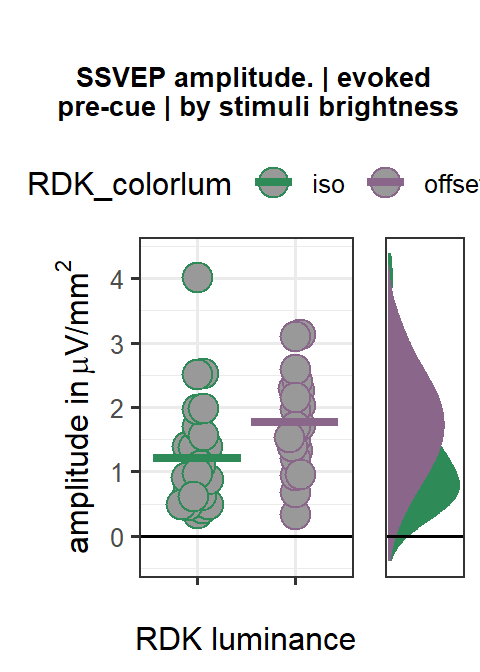

```r
#evoked raw#### for center

# set overall limits?
dat2plot <- DataIn %>%
  filter(
    RDK_ispresented=="presented",
    RDK_position1=="center",
    RDK_freq == 26,
    time == '[-1 0] ')%>%
  group_by(subjects, RDK_colorlum)%>%
  summarise( amplitude_evoked=mean(amplitude_evoked))
# set limits
yax_limits <- c( 0, max(dat2plot$amplitude_evoked))
yax_limits <- round(yax_limits + c(-1, 1)*diff(yax_limits)*0.1)
yax_limits <- yax_limits + c(-1, 1)*diff(yax_limits)*0.1




theme_set(theme_bw())
plot1 <- ggplot(dat2plot, aes(x = RDK_colorlum, y = amplitude_evoked, fill = RDK_colorlum)) +
  geom_hline(yintercept=0, show.legend = FALSE) +
  # geom_line(aes(group = interaction(subjects,time)),colour = "grey60",alpha = 1,size =0.5) +
  geom_beeswarm(aes(color = RDK_colorlum, x = RDK_colorlum,
                    group = RDK_colorlum), cex=3, size = 5,alpha=1,fill="grey60",shape=21)+
  # geom_point(aes(color = RDK_isattended, x = interaction(time,RDK_isattended),
  #                   group = RDK_isattended), size = 4,alpha=0.4)+
  stat_summary(fun.y=mean, aes(ymin=..y.., ymax=..y.., color =RDK_colorlum), geom='errorbar', width=0.9, size=1.5) +
  scale_x_discrete("RDK luminance", breaks=waiver(), labels = rep(c(""),1,2)) +
  # theme(legend.position="bottom") +
  ylab(expression(paste("amplitude in ", mu, "V/mm"^2)))+
  scale_fill_manual(values=c("seagreen", "plum4"), labels=c("iso", "offset"))+
  scale_color_manual(values=c("seagreen", "plum4"), labels=c("iso", "offset"))+
  #  scale_fill_manual(values=c("#193A3D", "#F03F3F"))+
  # scale_color_manual(values=c("#193A3D", "#F03F3F"))+
  # scale_fill_manual(values=c(rgb2hex(0.0, 153.0, 204.0),rgb2hex(0.0, 77, 102.0)))+
  # scale_color_manual(values=c(rgb2hex(0.0, 153.0, 204.0),rgb2hex(0.0, 77, 102.0)))+
  theme(legend.position="none")+
  # scale_y_continuous(limits=c(-60, 140))
  scale_y_continuous(limits=yax_limits)


plot2 <- ggplot(dat2plot, aes(y = amplitude_evoked, fill = RDK_colorlum, x = 1)) +
  geom_flat_violin(aes(fill = RDK_colorlum),position = position_nudge(x = .1, y = 0),
                   adjust = 1.3, trim = FALSE, alpha = 1, colour = NA)+
  geom_hline(yintercept=0, show.legend = FALSE) +
  # scale_fill_manual(values=c("#193A3D", "#F03F3F"))+
  # scale_color_manual(values=c("#193A3D", "#F03F3F"))+
  scale_fill_manual(values=c("seagreen", "plum4"), labels=c("iso", "offset"))+
  scale_color_manual(values=c("seagreen", "plum4"), labels=c("iso", "offset"))+
  # scale_fill_manual(values=c(rgb2hex(0.0, 153.0, 204.0),rgb2hex(0.0, 77, 102.0)))+
  # scale_color_manual(values=c(rgb2hex(0.0, 153.0, 204.0),rgb2hex(0.0, 77, 102.0)))+
  theme(axis.title.y=element_blank(),
        axis.text.y=element_blank(),
        axis.ticks.y=element_blank())+
  theme(axis.title.x=element_blank(),
        axis.text.x=element_blank(),
        axis.ticks.x=element_blank())+
  theme(panel.grid.major = element_blank(), panel.grid.minor = element_blank())+
  # scale_y_continuous(limits=c(-60, 140))
  scale_y_continuous(limits=yax_limits)



# cowplot::plot_grid(plot1, plot2, plot3, ncol = 3,labels = "AUTO")
plotttitle <- ggdraw() +
  draw_label("SSVEP amplitude. | evoked \npre-cue | by stimuli brightness",
             fontface='bold', size = 10)
plotplots <- ggarrange(plot1, plot2,ncol = 2,common.legend = TRUE,align = "h", widths=c(3,1))

savefig <- multi_panel_figure(columns = 1, rows = 1, panel_label_type = "none", width = 2.5, height = 3.5, unit = "in")
saveplot <- ggarrange(plotttitle, plotplots, nrow = 2, heights=c(0.2, 1))

savefig %<>%
  fill_panel(saveplot, column = 1, row = 1)
savefig
```

```r
# save_multi_panel_figure(savefig, "figures/FFT_BeeSwarm_Mod_ALPHA_COL_34subs.eps")
```

### 2d Illustrate Data as is | both subsets | attention effects

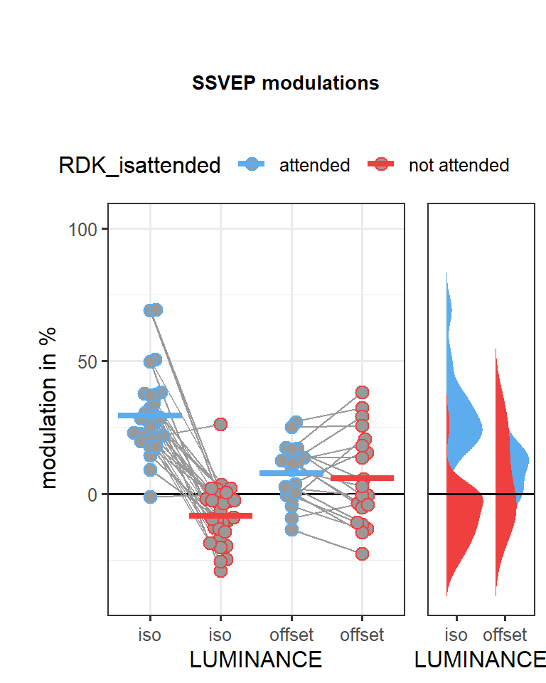

```r
#evoked raw#### for center

# set overall limits?
dat2plot <- DataIn %>%
  filter(RDK_ispresented=="presented", RDK_position1=="center")%>%
  group_by(subjects, time, RDK_colorlum,RDK_isattended)%>%
  summarise( modulation_evoked=mean(modulation_evoked))%>%
  filter(time == '[0.5 1.5] ')
# set limits
yax_limits <- c( min(dat2plot$modulation_evoked), max(dat2plot$modulation_evoked))
yax_limits <- round(yax_limits + c(-1, 1)*diff(yax_limits)*0.1)
yax_limits <- yax_limits + c(-0, 2)*diff(yax_limits)*0.1



theme_set(theme_bw())
plot1 <- ggplot(dat2plot, aes(x = interaction(RDK_isattended,RDK_colorlum), y = modulation_evoked, fill = RDK_isattended)) +
  geom_hline(yintercept=0, show.legend = FALSE) +
  geom_line(aes(group = interaction(subjects,RDK_colorlum)),colour = "grey60",alpha = 1,size =0.5) +
  geom_beeswarm(aes(color = RDK_isattended, x = interaction(RDK_isattended,RDK_colorlum),
                    group = RDK_isattended), cex=2, size = 3,alpha=1,fill="grey60",shape=21)+
  # geom_point(aes(color = RDK_isattended, x = interaction(time,RDK_isattended),
  #                   group = RDK_isattended), size = 4,alpha=0.4)+
  stat_summary(fun.y=mean, aes(ymin=..y.., ymax=..y.., color =RDK_isattended), geom='errorbar', width=0.9, size=1.5) +
  scale_x_discrete("LUMINANCE", breaks=waiver(), labels = c("iso","iso","offset","offset")) +
  # theme(legend.position="bottom") +
  # ylab(expression("amplitude in " * mu * "V/m²"))+
  ylab(expression("modulation in %"))+
  # scale_fill_manual(values=c("#005b8a", "#943826"))+
  # scale_color_manual(values=c("#005b8a", "#943826"))+
  # scale_fill_manual(values=c("seagreen", "plum4"))+
  # scale_color_manual(values=c("seagreen", "plum4"))+
  scale_fill_manual(values=c("steelblue2", "#F03F3F"))+
  scale_color_manual(values=c("steelblue2", "#F03F3F"))+
  #  scale_fill_manual(values=c("#193A3D", "#F03F3F"))+
  # scale_color_manual(values=c("#193A3D", "#F03F3F"))+
  # scale_fill_manual(values=c(rgb2hex(0.0, 153.0, 204.0),rgb2hex(0.0, 77, 102.0)))+
  # scale_color_manual(values=c(rgb2hex(0.0, 153.0, 204.0),rgb2hex(0.0, 77, 102.0)))+
  theme(legend.position="none")+
  # scale_y_continuous(limits=c(-60, 140))
  scale_y_continuous(limits=yax_limits)


plot2 <- ggplot(dat2plot, aes(y = modulation_evoked, fill = RDK_isattended, x = RDK_colorlum)) +
  geom_flat_violin(aes(fill = RDK_isattended, width = 1.5),
                   position = position_nudge(x = -0.2, y = 0),
                   adjust = 1, trim = FALSE, alpha = 1, colour = NA)+
  geom_hline(yintercept=0, show.legend = FALSE) +
  # scale_fill_manual(values=c("#193A3D", "#F03F3F"))+
  # scale_color_manual(values=c("#193A3D", "#F03F3F"))+
  scale_fill_manual(values=c("steelblue2", "#F03F3F"))+
  scale_color_manual(values=c("steelblue2", "#F03F3F"))+
  # scale_fill_manual(values=c("#005b8a", "#943826"))+
  # scale_color_manual(values=c("#005b8a", "#943826"))+
  # scale_fill_manual(values=c("seagreen", "plum4"))+
  # scale_color_manual(values=c("seagreen", "plum4"))+
  # scale_fill_manual(values=c(rgb2hex(0.0, 153.0, 204.0),rgb2hex(0.0, 77, 102.0)))+
  # scale_color_manual(values=c(rgb2hex(0.0, 153.0, 204.0),rgb2hex(0.0, 77, 102.0)))+
  theme(axis.title.y=element_blank(),
        axis.text.y=element_blank(),
        axis.ticks.y=element_blank())+
  # theme(axis.title.x=element_blank(),
  #       axis.text.x=element_blank(),
  #       axis.ticks.x=element_blank())+
  scale_x_discrete("LUMINANCE", breaks=waiver(), labels = c("iso","offset")) +
  theme(panel.grid.major = element_blank(), panel.grid.minor = element_blank())+
  # scale_y_continuous(limits=c(-60, 140))
  scale_y_continuous(limits=yax_limits)



# cowplot::plot_grid(plot1, plot2, plot3, ncol = 3,labels = "AUTO")
plotttitle <- ggdraw() +
  draw_label("SSVEP modulations", fontface='bold', size = 10)
plotplots <- ggarrange(plot1, plot2,ncol = 2,common.legend = TRUE,align = "h", widths=c(3,1))

savefig <- multi_panel_figure(columns = 1, rows = 1, panel_label_type = "none", width = 4, height = 5, unit = "in")
saveplot <- ggarrange(plotttitle, plotplots, nrow = 2, heights=c(0.2, 1))

savefig %<>%
  fill_panel(saveplot, column = 1, row = 1)
savefig
```

```r
# save_multi_panel_figure(savefig, "figures/FFT_AttMod_2studies.eps")
```

## Statistical analysis

### Central Stimuli

#### analysis I

**modulation** ~ **COLOR ATTENTION** x **COLOR LUMINANCE**

- mixed design
- t-test post-cue modulation against zero for attended and unattended color
- t-test difference of post-cue modulation for attended vs unattended color

```r
dat2plot <- DataIn %>%
  filter(RDK_position2=="center") %>%
  group_by(subjects, time, RDK_isattended, RDK_colorlum)%>%
  summarise(amplitude_evoked=mean(amplitude_evoked), modulation_evoked=mean(modulation_evoked))%>%
  filter(time == '[0.5 1.5] ')%>%
  ungroup

aovmodel1 <- dat2plot%>%
  aov_ez(id="subjects", dv = "modulation_evoked", data = ., within = c("RDK_isattended"), between = c("RDK_colorlum"),
         include_aov = afex_options("include_aov"))


# display table anova effects
aovmodel1 %>%
  anova()%>%
  tidy()%>%
  mutate(
    `p.value` = cell_spec(ifelse(round(`p.value`,4)<.001,"< .001",round(`p.value`,4)),
                        color = ifelse(is.nan(`p.value`),"blue", ifelse(`p.value` < .05, "green", "red")),
                        bold = ifelse(is.nan(`p.value`),F, ifelse(`p.value` < .05, T,F)),
                        align = "center")
  ) %>%
  dplyr::select(term, `num.Df`, `den.Df`, MSE, `statistic`, ges, `p.value`) %>%
  dplyr::rename(F=statistic)%>%
  kbl(escape = F, digits = c(5,5,5,5,5,5,5,5,5), caption = c("repeated measures ANOVA for central post-cue modulations")) %>%
  kable_styling("striped", full_width = T, bootstrap_options = c("striped", "hover", "condensed", "responsive",font_size = 8))
```

repeated measures ANOVA for central post-cue modulations

| term | num.Df | den.Df | MSE | F | ges | p.value |
| --- | --- | --- | --- | --- | --- | --- |
| RDK_colorlum | 1 | 48 | 249.5180 | 1.42537 | 0.01894 | 0.2384 |
| RDK_isattended | 1 | 48 | 134.2269 | 70.66108 | 0.33990 | < .001 |
| RDK_colorlum:RDK_isattended | 1 | 48 | 134.2269 | 57.39727 | 0.29491 | < .001 |

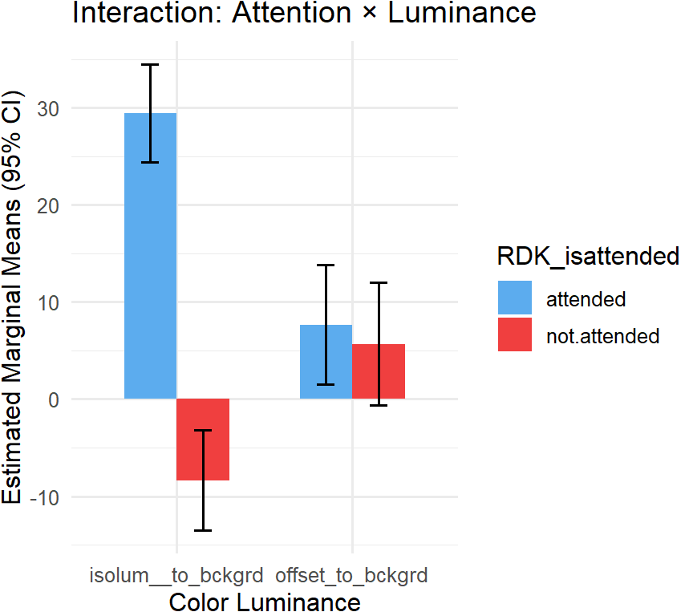

```r
#display interaction
emm_ATTXLum <- as.data.frame(emmeans(aovmodel1, ~ RDK_isattended*RDK_colorlum))

# RDK_isattended plot
ggplot(emm_ATTXLum, aes(x = RDK_colorlum, y = emmean, fill = RDK_isattended)) +
  geom_col(position = position_dodge(), width = 0.6) +
  geom_errorbar(aes(ymin = lower.CL, ymax = upper.CL),
                position = position_dodge(width = 0.6),
                width = 0.2) +
  labs(title = "Interaction: Attention × Luminance",
       y = "Estimated Marginal Means (95% CI)", x = "Color Luminance") +
  theme_minimal()+
  scale_fill_manual(values=c("steelblue2", "#F03F3F"))+
  scale_color_manual(values=c("steelblue2", "#F03F3F"))
```

```r
#create emmeans object/grid
post_hocs.emmean <- emmeans(aovmodel1, c("RDK_isattended","RDK_colorlum")) # adjust = holm

# report data for post_hocs.RDK_isattended
post_hocs.emmean %>%
  kbl(escape = F, digits = c(3,3,3,3,3,3,3,3,3),
      caption = c("estimated marginal means | by ATTENTION X LUMINANCE | dv = central SSVEP modulation")) %>%
  kable_styling("striped", full_width = T, bootstrap_options = c("striped", "hover", "condensed", "responsive",font_size = 8))
```

estimated marginal means | by ATTENTION X LUMINANCE | dv = central SSVEP modulation

| RDK_isattended | RDK_colorlum | emmean | SE | df | lower.CL | upper.CL |
| --- | --- | --- | --- | --- | --- | --- |
| attended | isolum__to_bckgrd | 29.424 | 2.497 | 48 | 24.404 | 34.443 |
| not.attended | isolum__to_bckgrd | -8.373 | 2.561 | 48 | -13.522 | -3.223 |
| attended | offset_to_bckgrd | 7.657 | 3.058 | 48 | 1.509 | 13.805 |
| not.attended | offset_to_bckgrd | 5.695 | 3.137 | 48 | -0.612 | 12.001 |

```r
post_hocs.emmean %>%
contrast(method = "identity",adjust = "FDR")%>%
summary() %>%
  mutate(
    p.value = cell_spec(ifelse(round(p.value,4)<.001,"< .001",round(p.value,4)),
                        color = ifelse(is.nan(p.value),"blue", ifelse(p.value < .05, "green", "red")),
                        bold = ifelse(is.nan(p.value),F, ifelse(p.value < .05, T,F)),
                        align = "left")
  ) %>%
  # mutate(CohensD = `t.ratio`/sqrt(df+1))%>%
  mutate(`CohensD` =
           summary(eff_size(contrast(post_hocs.emmean,method = "identity",adjust = "FDR"),
                            sigma = sqrt(mean(sigma(aovmodel1$lm)^2)), # RMS of sigma()
                            edf = df.residual(aovmodel1$lm), method = "identity"))$effect.size,
         `lowCI` =
           summary(eff_size(contrast(post_hocs.emmean,method = "identity",adjust = "FDR"),
                            sigma = sqrt(mean(sigma(aovmodel1$lm)^2)), # RMS of sigma()
                            edf = df.residual(aovmodel1$lm), method = "identity"))$lower.CL,
         `highCI` =
           summary(eff_size(contrast(post_hocs.emmean,method = "identity",adjust = "FDR"),
                            sigma = sqrt(mean(sigma(aovmodel1$lm)^2)), # RMS of sigma()
                            edf = df.residual(aovmodel1$lm), method = "identity"))$upper.CL
  )%>%
  kbl(escape = F, digits = c(3,3,3,3,3,3,3,3,3),
        caption = c("estimated marginal means | by ATTENTION X LUMINANCE | dv = central SSVEP modulation | corrected: FDR")) %>%
  kable_styling("striped", full_width = T, bootstrap_options = c("striped", "hover", "condensed", "responsive",font_size = 8))
```

estimated marginal means | by ATTENTION X LUMINANCE | dv = central SSVEP modulation | corrected: FDR

| contrast | estimate | SE | df | t.ratio | p.value | CohensD | lowCI | highCI |
| --- | --- | --- | --- | --- | --- | --- | --- | --- |
| attended isolum__to_bckgrd | 29.424 | 2.497 | 48 | 11.785 | < .001 | 2.124 | 1.557 | 2.691 |
| not.attended isolum__to_bckgrd | -8.373 | 2.561 | 48 | -3.269 | 0.004 | -0.604 | -0.996 | -0.213 |
| attended offset_to_bckgrd | 7.657 | 3.058 | 48 | 2.504 | 0.021 | 0.553 | 0.095 | 1.011 |
| not.attended offset_to_bckgrd | 5.695 | 3.137 | 48 | 1.816 | 0.0757 | 0.411 | -0.052 | 0.874 |

```r
# planned comparison
# test by specifying the levels levels(post_hocs.emmean) as.data.frame(post_hocs.emmean)
list.contrasts <- list(
  "iso att vs unatt"=c(1, -1, 0, 0),
  "offset att vs unatt"=c(0, 0, 1, -1),
  "att iso vs offset"=c(1,0,-1,0),
  "unatt iso vs offset"=c(0, 1, 0, -1)
)



post_hocs.emmean %>%
  contrast(method = list.contrasts,adjust = "FDR") %>%
  summary() %>%
  mutate(
    p.value = cell_spec(ifelse(round(p.value,4)<.001,"< .001",round(p.value,4)),
                        color = ifelse(is.nan(p.value),"blue", ifelse(p.value < .05, "green", "red")),
                        bold = ifelse(is.nan(p.value),F, ifelse(p.value < .05, T,F)),
                        align = "left")
  ) %>%
  # mutate(CohensD = `t.ratio`/sqrt(df+1))%>%
  mutate(`CohensD` =
           summary(eff_size(contrast(post_hocs.emmean, method = list.contrasts,adjust = "FDR"),
                            sigma = sqrt(mean(sigma(aovmodel1$lm)^2)), # RMS of sigma()
                            edf = df.residual(aovmodel1$lm), method = "identity"))$effect.size,
         `lowCI` =
           summary(eff_size(contrast(post_hocs.emmean, method = list.contrasts,adjust = "FDR"),
                            sigma = sqrt(mean(sigma(aovmodel1$lm)^2)), # RMS of sigma()
                            edf = df.residual(aovmodel1$lm), method = "identity"))$lower.CL,
         `highCI` =
           summary(eff_size(contrast(post_hocs.emmean, method = list.contrasts,adjust = "FDR"),
                            sigma = sqrt(mean(sigma(aovmodel1$lm)^2)), # RMS of sigma()
                            edf = df.residual(aovmodel1$lm), method = "identity"))$upper.CL
  )%>%
  kbl(escape = F, digits = c(3,3,3,3,3,3,3,3,3),
        caption = c("estimated contrasts | by ATTENTION X LUMINANCE | dv = central SSVEP modulation | corrected: FDR")) %>%
  kable_styling("striped", full_width = T, bootstrap_options = c("striped", "hover", "condensed", "responsive",font_size = 8))
```

estimated contrasts | by ATTENTION X LUMINANCE | dv = central SSVEP modulation | corrected: FDR

| contrast | estimate | SE | df | t.ratio | p.value | CohensD | lowCI | highCI |
| --- | --- | --- | --- | --- | --- | --- | --- | --- |
| iso att vs unatt | 37.796 | 2.991 | 48 | 12.635 | < .001 | 2.729 | 2.020 | 3.437 |
| offset att vs unatt | 1.963 | 3.664 | 48 | 0.536 | 0.5946 | 0.142 | -0.391 | 0.674 |
| att iso vs offset | 21.766 | 3.947 | 48 | 5.514 | < .001 | 1.571 | 0.914 | 2.229 |
| unatt iso vs offset | -14.067 | 4.049 | 48 | -3.474 | 0.0015 | -1.016 | -1.639 | -0.392 |

#### analysis II

**modulation** ~ **COLOR ATTENTION**

conventional analysis with anova and post-hoc t-tests implemented manually

- t-test post-cue modulation against zero for attended and unattended color
- t-test difference of post-cue modulation for attended vs unattended color

```r
dat2plot <- DataIn %>%
  filter(RDK_position2=="center") %>%
  group_by(subjects, time, RDK_isattended, RDK_colorlum)%>%
  summarise(amplitude_evoked=mean(amplitude_evoked), modulation_evoked=mean(modulation_evoked))%>%
  filter(time == '[0.5 1.5] ')


aovmodel1 <- dat2plot%>%
  aov_ez(id="subjects", dv = "modulation_evoked", data = ., within = c("RDK_isattended"), between = c("RDK_colorlum"),
         include_aov = afex_options("include_aov"))


# display table anova effects
aovmodel1 %>%
  anova()%>%
  tidy()%>%
  mutate(
    `p.value` = cell_spec(ifelse(round(`p.value`,4)<.001,"< .001",round(`p.value`,4)),
                        color = ifelse(is.nan(`p.value`),"blue", ifelse(`p.value` < .05, "green", "red")),
                        bold = ifelse(is.nan(`p.value`),F, ifelse(`p.value` < .05, T,F)),
                        align = "center")
  ) %>%
  dplyr::select(term, `num.Df`, `den.Df`, MSE, `statistic`, ges, `p.value`) %>%
  dplyr::rename(F=statistic)%>%
  kbl(escape = F, digits = c(5,5,5,5,5,5,5,5,5), caption = c("Mixed effects ANOVA model for central post-cue modulations")) %>%
  kable_styling("striped", full_width = T, bootstrap_options = c("striped", "hover", "condensed", "responsive",font_size = 8))
```

Mixed effects ANOVA model for central post-cue modulations

| term | num.Df | den.Df | MSE | F | ges | p.value |
| --- | --- | --- | --- | --- | --- | --- |
| RDK_colorlum | 1 | 48 | 249.5180 | 1.42537 | 0.01894 | 0.2384 |
| RDK_isattended | 1 | 48 | 134.2269 | 70.66108 | 0.33990 | < .001 |
| RDK_colorlum:RDK_isattended | 1 | 48 | 134.2269 | 57.39727 | 0.29491 | < .001 |

```r
dat2plot %>%
  group_by(RDK_isattended, RDK_colorlum)%>%
  nest()%>%
  mutate(stats = map(data, ~broom::tidy(
    t.test(modulation_evoked ~ 1, data = .)
  ))) %>%
  mutate(
    t_test_bf = map(data, ~{extractBF(ttestBF(x = .$modulation_evoked, data = .,iterations=num.iter,rscale = sqrt(2)/2))})
  )%>%
  mutate(meanval = map(data, ~ mean(.x$modulation_evoked))) %>%
  mutate(std = map(data, ~ sd(.x$modulation_evoked))) %>%
  dplyr::select(-data) %>%
  unnest(cols = c(stats, t_test_bf, meanval, std))%>%
  mutate(BF10 = bf, BF01 = 1/bf)%>%
  dplyr::select(RDK_colorlum, RDK_isattended, meanval, std,  statistic, parameter, p.value, BF10, BF01)%>%
  ungroup()%>%
  # group_by(RDK_colorlum)%>%
  mutate(p.value = p.adjust(p.value, method="fdr")) %>% # none, holm
  # mutate(p.value = p.adjust(p.value, method="none")) %>% # none, holm
  ungroup()%>%
  mutate(CohensD = `statistic`/sqrt(parameter +1))%>%
  mutate(
    p.value = cell_spec(ifelse(round(p.value,4)<.001,"< .001",round(p.value,4)),
                        color = ifelse(is.nan(p.value),"blue", ifelse(p.value < .05, "green", "red")),
                        bold = ifelse(is.nan(p.value),F, ifelse(p.value < .05, T,F)),
                        align = "center")
  ) %>%
  kbl(escape = F, digits = c(3,3,3,3,3,3,3,3,3),
        caption = c("central SSVEP | modulation | t-tests for modulation agains zero | FDR-corrected")) %>%
  kable_styling("striped", full_width = T, bootstrap_options = c("striped", "hover", "condensed", "responsive",font_size = 8))
```

central SSVEP | modulation | t-tests for modulation agains zero | FDR-corrected

| RDK_colorlum | RDK_isattended | meanval | std | statistic | parameter | p.value | BF10 | BF01 | CohensD |
| --- | --- | --- | --- | --- | --- | --- | --- | --- | --- |
| offset_to_bckgrd | attended | 7.657 | 10.844 | 3.158 | 19 | 0.0069 | 8.904 | 0.112 | 0.706 |
| offset_to_bckgrd | not attended | 5.695 | 17.495 | 1.456 | 19 | 0.1618 | 0.577 | 1.732 | 0.325 |
| isolum__to_bckgrd | attended | 29.424 | 15.247 | 10.570 | 29 | < .001 | 496550591.438 | 0.000 | 1.930 |
| isolum__to_bckgrd | not attended | -8.373 | 11.186 | -4.100 | 29 | < .001 | 95.229 | 0.011 | -0.749 |

```r
dat2plot %>%
  dplyr::select(-amplitude_evoked)%>%
  pivot_wider(names_from = "RDK_isattended", values_from = "modulation_evoked")%>%
  mutate(attendedMINUSunattended = `attended` -`not attended`)%>%
  group_by(time, RDK_colorlum)%>%
  nest()%>%
  mutate(stats = map(data, ~broom::tidy(
    t.test(attendedMINUSunattended ~ 1, data = .)
  ))) %>%
  mutate(
    t_test_bf = map(data, ~{extractBF(ttestBF(x = .$attendedMINUSunattended, data = .,iterations=num.iter,rscale = sqrt(2)/2))})
  )%>%
  mutate(meanval = map(data, ~ mean(.x$attendedMINUSunattended))) %>%
  mutate(std = map(data, ~ sd(.x$attendedMINUSunattended))) %>%
  ungroup()%>%
  dplyr::select(-data, -time) %>%
  unnest(cols = c(stats, t_test_bf, meanval, std))%>%
  mutate(BF10 = bf, BF01 = 1/bf)%>%
  dplyr::select(RDK_colorlum, meanval, std,  statistic, parameter, p.value, BF10, BF01)%>%
  ungroup()%>%
  mutate(p.value = p.adjust(p.value, method="fdr")) %>% # none, holm
  # mutate(p.value = p.adjust(p.value, method="none")) %>% # none, holm
  ungroup()%>%
  mutate(CohensD = `statistic`/sqrt(parameter +1))%>%
  mutate(
    p.value = cell_spec(ifelse(round(p.value,4)<.001,"< .001",round(p.value,4)),
                        color = ifelse(is.nan(p.value),"blue", ifelse(p.value < .05, "green", "red")),
                        bold = ifelse(is.nan(p.value),F, ifelse(p.value < .05, T,F)),
                        align = "center")
  ) %>%
  kbl(escape = F, digits = c(3,3,3,3,3,3,3,3,3), caption = c("central SSVEP | modulation | attended - unattended ")) %>%
  kable_styling("striped", full_width = T, bootstrap_options = c("striped", "hover", "condensed", "responsive",font_size = 8))
```

central SSVEP | modulation | attended - unattended

| RDK_colorlum | meanval | std | statistic | parameter | p.value | BF10 | BF01 | CohensD |
| --- | --- | --- | --- | --- | --- | --- | --- | --- |
| offset_to_bckgrd | 1.963 | 12.859 | 0.683 | 19 | 0.5031 | 2.86000e-01 | 3.494 | 0.153 |
| isolum__to_bckgrd | 37.796 | 18.330 | 11.294 | 29 | < .001 | 2.18099e+09 | 0.000 | 2.062 |

#### analysis IIc

**modulation** ~ **COLOR ATTENTION**

control analysis for 26 Hz signal only conventional analysis with anova and post-hoc t-tests implemented manually

- t-test post-cue modulation against zero for attended and unattended color
- t-test difference of post-cue modulation for attended vs unattended color

```r
dat2plot <- DataIn %>%
  filter(RDK_position2=="center", RDK_freq==26) %>%
  group_by(subjects, time, RDK_isattended, RDK_colorlum)%>%
  summarise(amplitude_evoked=mean(amplitude_evoked), modulation_evoked=mean(modulation_evoked))%>%
  filter(time == '[0.5 1.5] ')


aovmodel1 <- dat2plot%>%
  aov_ez(id="subjects", dv = "modulation_evoked", data = ., within = c("RDK_isattended"), between = c("RDK_colorlum"),
         include_aov = afex_options("include_aov"))


# display table anova effects
aovmodel1 %>%
  anova()%>%
  tidy()%>%
  mutate(
    `p.value` = cell_spec(ifelse(round(`p.value`,4)<.001,"< .001",round(`p.value`,4)),
                        color = ifelse(is.nan(`p.value`),"blue", ifelse(`p.value` < .05, "green", "red")),
                        bold = ifelse(is.nan(`p.value`),F, ifelse(`p.value` < .05, T,F)),
                        align = "center")
  ) %>%
  dplyr::select(term, `num.Df`, `den.Df`, MSE, `statistic`, ges, `p.value`) %>%
  dplyr::rename(F=statistic)%>%
  kbl(escape = F, digits = c(5,5,5,5,5,5,5,5,5), caption = c("Mixed effects ANOVA model for central post-cue modulations 26 Hz only")) %>%
  kable_styling("striped", full_width = T, bootstrap_options = c("striped", "hover", "condensed", "responsive",font_size = 8))
```

Mixed effects ANOVA model for central post-cue modulations 26 Hz only

| term | num.Df | den.Df | MSE | F | ges | p.value |
| --- | --- | --- | --- | --- | --- | --- |
| RDK_colorlum | 1 | 48 | 392.4957 | 2.70477 | 0.03317 | 0.1066 |
| RDK_isattended | 1 | 48 | 252.0760 | 28.67979 | 0.18941 | < .001 |
| RDK_colorlum:RDK_isattended | 1 | 48 | 252.0760 | 31.99391 | 0.20677 | < .001 |

```r
dat2plot %>%
  group_by(RDK_isattended, RDK_colorlum)%>%
  nest()%>%
  mutate(stats = map(data, ~broom::tidy(
    t.test(modulation_evoked ~ 1, data = .)
  ))) %>%
  mutate(
    t_test_bf = map(data, ~{extractBF(ttestBF(x = .$modulation_evoked, data = .,iterations=num.iter,rscale = sqrt(2)/2))})
  )%>%
  mutate(meanval = map(data, ~ mean(.x$modulation_evoked))) %>%
  mutate(std = map(data, ~ sd(.x$modulation_evoked))) %>%
  dplyr::select(-data) %>%
  unnest(cols = c(stats, t_test_bf, meanval, std))%>%
  mutate(BF10 = bf, BF01 = 1/bf)%>%
  dplyr::select(RDK_colorlum, RDK_isattended, meanval, std,  statistic, parameter, p.value, BF10, BF01)%>%
  ungroup()%>%
  # group_by(RDK_colorlum)%>%
  mutate(p.value = p.adjust(p.value, method="fdr")) %>% # none, holm
  # mutate(p.value = p.adjust(p.value, method="none")) %>% # none, holm
  ungroup()%>%
  mutate(CohensD = `statistic`/sqrt(parameter +1))%>%
  mutate(
    p.value = cell_spec(ifelse(round(p.value,4)<.001,"< .001",round(p.value,4)),
                        color = ifelse(is.nan(p.value),"blue", ifelse(p.value < .05, "green", "red")),
                        bold = ifelse(is.nan(p.value),F, ifelse(p.value < .05, T,F)),
                        align = "center")
  ) %>%
  kbl(escape = F, digits = c(3,3,3,3,3,3,3,3,3),
        caption = c("central SSVEP 26 Hz only | modulation | t-tests for modulation agains zero | FDR-corrected")) %>%
  kable_styling("striped", full_width = T, bootstrap_options = c("striped", "hover", "condensed", "responsive",font_size = 8))
```

central SSVEP 26 Hz only | modulation | t-tests for modulation agains zero | FDR-corrected

| RDK_colorlum | RDK_isattended | meanval | std | statistic | parameter | p.value | BF10 | BF01 | CohensD |
| --- | --- | --- | --- | --- | --- | --- | --- | --- | --- |
| offset_to_bckgrd | attended | 4.558 | 16.962 | 1.202 | 19 | 0.2442 | 0.436 | 2.291 | 0.269 |
| offset_to_bckgrd | not attended | 5.533 | 19.155 | 1.292 | 19 | 0.2442 | 0.480 | 2.085 | 0.289 |
| isolum__to_bckgrd | attended | 29.540 | 20.833 | 7.766 | 29 | < .001 | 914344.933 | 0.000 | 1.418 |
| isolum__to_bckgrd | not attended | -6.147 | 14.282 | -2.358 | 29 | 0.0507 | 2.072 | 0.483 | -0.430 |

```r
dat2plot %>%
  dplyr::select(-amplitude_evoked)%>%
  pivot_wider(names_from = "RDK_isattended", values_from = "modulation_evoked")%>%
  mutate(attendedMINUSunattended = `attended` -`not attended`)%>%
  group_by(time, RDK_colorlum)%>%
  nest()%>%
  mutate(stats = map(data, ~broom::tidy(
    t.test(attendedMINUSunattended ~ 1, data = .)
  ))) %>%
  mutate(
    t_test_bf = map(data, ~{extractBF(ttestBF(x = .$attendedMINUSunattended, data = .,iterations=num.iter,rscale = sqrt(2)/2))})
  )%>%
  mutate(meanval = map(data, ~ mean(.x$attendedMINUSunattended))) %>%
  mutate(std = map(data, ~ sd(.x$attendedMINUSunattended))) %>%
  ungroup()%>%
  dplyr::select(-data, -time) %>%
  unnest(cols = c(stats, t_test_bf, meanval, std))%>%
  mutate(BF10 = bf, BF01 = 1/bf)%>%
  dplyr::select(RDK_colorlum, meanval, std,  statistic, parameter, p.value, BF10, BF01)%>%
  ungroup()%>%
  mutate(p.value = p.adjust(p.value, method="fdr")) %>% # none, holm
  # mutate(p.value = p.adjust(p.value, method="none")) %>% # none, holm
  ungroup()%>%
  mutate(CohensD = `statistic`/sqrt(parameter +1))%>%
  mutate(
    p.value = cell_spec(ifelse(round(p.value,4)<.001,"< .001",round(p.value,4)),
                        color = ifelse(is.nan(p.value),"blue", ifelse(p.value < .05, "green", "red")),
                        bold = ifelse(is.nan(p.value),F, ifelse(p.value < .05, T,F)),
                        align = "center")
  ) %>%
  kbl(escape = F, digits = c(3,3,3,3,3,3,3,3,3), caption = c("central SSVEP 26 Hz only | modulation | attended - unattended ")) %>%
  kable_styling("striped", full_width = T, bootstrap_options = c("striped", "hover", "condensed", "responsive",font_size = 8))
```

central SSVEP 26 Hz only | modulation | attended - unattended

| RDK_colorlum | meanval | std | statistic | parameter | p.value | BF10 | BF01 | CohensD |
| --- | --- | --- | --- | --- | --- | --- | --- | --- |
| offset_to_bckgrd | -0.975 | 18.428 | -0.237 | 19 | 0.8154 | 0.238 | 4.197 | -0.053 |
| isolum__to_bckgrd | 35.687 | 24.738 | 7.901 | 29 | < .001 | 1263819.549 | 0.000 | 1.443 |

#### analysis III

**PRE-CUE AMP** ~ **COLOR LUMINANCE**

- t-test of pre-cue 26 Hz amplitudes between isoluminat colors and colors with offset

```r
dat2plot <- DataIn %>%
  filter(
    RDK_ispresented=="presented",
    RDK_position1=="center",
    RDK_freq == 26,
    time == '[-1 0] ')%>%
  group_by(subjects, RDK_colorlum)%>%
  summarise( amplitude_evoked=mean(amplitude_evoked))

dat2plot %>%
  ungroup()%>%
  nest() %>%
  mutate(
    stats = map(data, ~ broom::tidy(t.test(amplitude_evoked ~ RDK_colorlum, data = .))),
    t_test_bf = map(data, ~ extractBF(ttestBF(formula = amplitude_evoked ~ RDK_colorlum,
                                              data = ., iterations = num.iter, rscale = sqrt(2)/2))),
    meanval = map(data, ~ .x %>%
                    group_by(RDK_colorlum) %>%
                    summarise(
                      mean_AMP_Mean = mean(amplitude_evoked, na.rm = TRUE),
                      std_AMP_Mean = sd(amplitude_evoked, na.rm = TRUE)
                    ) %>%
                    pivot_wider(names_from = RDK_colorlum,
                                values_from = c(mean_AMP_Mean, std_AMP_Mean),
                                names_sep = "_")
    ),
    cohens_d = map(data, ~ rstatix::cohens_d(amplitude_evoked ~ RDK_colorlum, data = ., paired = FALSE))
  ) %>%
  unnest(cols = c(stats, cohens_d, t_test_bf, meanval))%>%
  mutate(BF10 = bf, BF01 = 1/bf,
         M_AMP_iso = mean_AMP_Mean_isolum__to_bckgrd,
         SD_AMP_iso = std_AMP_Mean_isolum__to_bckgrd,
         M_AMP_off = mean_AMP_Mean_offset_to_bckgrd,
         SD_AMP_off = std_AMP_Mean_offset_to_bckgrd,
         diff=estimate,
         CohensD = effsize, t.value=statistic, df = parameter)%>%
  dplyr::select(M_AMP_iso, SD_AMP_iso, M_AMP_off, SD_AMP_off, diff, t.value, df, p.value, CohensD, BF10, BF01)%>%
  mutate(
    p.value = cell_spec(ifelse(round(p.value,4)<.001,"< .001",round(p.value,4)),
                        color = ifelse(is.nan(p.value),"blue", ifelse(p.value < .05, "green", "red")),
                        bold = ifelse(is.nan(p.value),F, ifelse(p.value < .05, T,F)),
                        align = "center")
  ) %>%
  kbl(escape = F, digits = c(3,3,3,3,3,3,3,3,3), caption = c("central SSVEP | amplitude | pre-cue ")) %>%
  kable_styling("striped", full_width = T, bootstrap_options = c("striped", "hover", "condensed", "responsive",font_size = 8))
```

central SSVEP | amplitude | pre-cue

| M_AMP_iso | SD_AMP_iso | M_AMP_off | SD_AMP_off | diff | t.value | df | p.value | CohensD | BF10 | BF01 |
| --- | --- | --- | --- | --- | --- | --- | --- | --- | --- | --- |
| 1.204 | 0.802 | 1.763 | 0.755 | -0.559 | -2.502 | 42.56 | 0.0163 | -0.718 | 3.215 | 0.311 |

#### analysis IV

**modulation** ~ **COLOR ATTENTION**

Bayesian analysis via brms to allow inclusion of Bayes Factor estimation for mixed models

```r
dat2plot <- DataIn %>%
  filter(RDK_position2=="center") %>%
  group_by(subjects, time, RDK_isattended, RDK_colorlum)%>%
  summarise(amplitude_evoked=mean(amplitude_evoked), modulation_evoked=mean(modulation_evoked))%>%
  filter(time == '[0.5 1.5] ')



# Fit the model
# (1 | subjects) accounts for the random intercept per subject
bayesian_model <- brm(
  formula = modulation_evoked ~ RDK_isattended * RDK_colorlum + (1 | subjects),
  data = dat2plot,
  family = gaussian(),
  prior = set_prior("normal(0, 20)", class = "b"), # Optional: set your priors
  # prior = set_prior("cauchy(0, 0.707)", class = "b"), # medium prior
  chains = 4, iter = 2000, core = 4,
  file = "fit_full_slog.rds",
  save_pars = save_pars(all = TRUE),
  file_refit = "on_change",
  # file_refit = "always",
  # file_refit = "never",
)

# (2 | subjects) fit the prior model only
bayesian_prior_model <- brm(
  formula = modulation_evoked ~ RDK_isattended * RDK_colorlum + (1 | subjects),
  data = dat2plot,
  family = gaussian(),
  prior = set_prior("normal(0, 20)", class = "b"), # Optional: set your priors
  # prior = set_prior("cauchy(0, 0.707)", class = "b"), # medium prior
  chains = 4, iter = 2000, core = 4,
  file = "fit_full_prior_slog.rds",
  save_pars = save_pars(all = TRUE),
  file_refit = "on_change",
  # file_refit = "always",
  # file_refit = "never",
  sample_prior = "only" # This ignores your actual DV values
)

# (3 | subjects) fit the null model only
bayesian_null_model <- brm(
  formula = modulation_evoked ~ 1 + (1 | subjects),
  data = dat2plot,
  family = gaussian(),
  prior = set_prior("normal(0, 20)", class = "Intercept"), # Optional: set your priors
  # prior = set_prior("cauchy(0, 0.707)", class = "b"), # medium prior
  chains = 4, iter = 2000, core = 4,
  file = "fit_null_slog.rds",
  save_pars = save_pars(all = TRUE),
  file_refit = "on_change",
  # file_refit = "always",
  # file_refit = "never",
)


# report results for some designed contrasts
# create emmmgrid
bayesian_emm <- emmeans(bayesian_model, ~ RDK_isattended * RDK_colorlum)

# defined contrasts
list.contrasts <- list(
  "iso att vs unatt"=c(1, -1, 0, 0),
  "offset att vs unatt"=c(0, 0, 1, -1),
  "att iso vs offset"=c(1,0,-1,0),
  "unatt iso vs offset"=c(0, 1, 0, -1)
)

# compute contrasts
bayesian_contrasts<-bayesian_emm %>%
  contrast(method = list.contrasts)

bayesian_contrasts %>%
  summary() %>%
    kbl(escape = F, digits = c(3,3,3,3,3,3,3,3,3),
        caption = c("estimated contrasts | by ATTENTION X LUMINANCE | dv = central SSVEP modulation | BRMs framework")) %>%
  kable_styling("striped", full_width = T, bootstrap_options = c("striped", "hover", "condensed", "responsive",font_size = 8))
```

estimated contrasts | by ATTENTION X LUMINANCE | dv = central SSVEP modulation | BRMs framework

| contrast | estimate | lower.HPD | upper.HPD |
| --- | --- | --- | --- |
| iso att vs unatt | 35.977 | 29.730 | 41.959 |
| offset att vs unatt | 3.490 | -3.702 | 11.177 |
| att iso vs offset | 19.521 | 10.879 | 26.920 |
| unatt iso vs offset | -12.889 | -21.033 | -4.996 |

```r
# no calculate Bayes factors for these contrasts
# Force the calculation to look at the samples
prior_model <- unupdate(bayesian_model)
prior_emm <- emmeans(prior_model, ~ RDK_isattended * RDK_colorlum)
prior_emm_contrasts <- prior_emm %>%
  contrast(method = list.contrasts)

bayesian_contrasts_BF <- bayesfactor_parameters(bayesian_contrasts, prior = prior_emm_contrasts)

bayesian_contrasts_BF%>%
  as.data.frame() %>%
  mutate(BF10 = exp(log_BF), BF01 = 1/exp(log_BF)) %>%
  # Optional: Round to 2 decimal places unless it's very small
  mutate(BF10 = ifelse(BF10 > 1000, formatC(BF10, format = "e", digits = 3), round(BF10, 3))) %>%
  mutate(BF01 = ifelse(BF01 > 1000, formatC(BF01, format = "e", digits = 3), round(BF01, 3))) %>%
  dplyr::select(contrast, BF10, BF01, -log_BF)%>%
    kbl(escape = F, digits = c(3,3,3,3,3,3,3,3,3),
        caption = c("estimated contrasts | by ATTENTION X LUMINANCE | dv = central SSVEP modulation | BRMs framework")) %>%
  kable_styling("striped", full_width = T, bootstrap_options = c("striped", "hover", "condensed", "responsive",font_size = 8))
```

estimated contrasts | by ATTENTION X LUMINANCE | dv = central SSVEP modulation | BRMs framework

| contrast | BF10 | BF01 |
| --- | --- | --- |
| iso att vs unatt | 1.733e+08 | 0.000 |
| offset att vs unatt | 0.196 | 5.091 |
| att iso vs offset | 908.868 | 0.001 |
| unatt iso vs offset | 21.71 | 0.046 |

#### analysis V

**CENTRAL PRE-CUE AMP** ~ **PRESENCE IN PERIPHERY**

Do we see differences in pre-cue SSVEP amplitudes depending on whether the stimulus of the same color was present in the periphery?

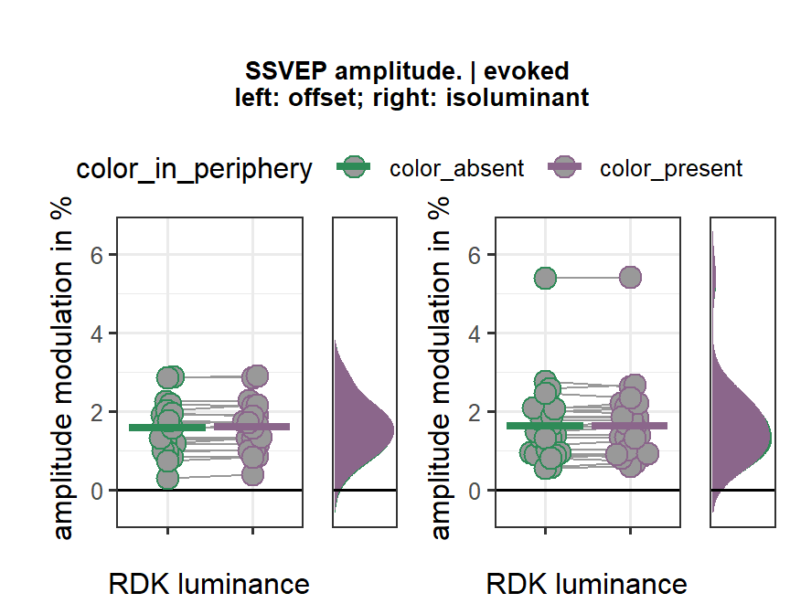

```r
dat2plot <- DataIn %>%
  filter(time == '[-1 0] ') %>%
  group_by(subjects, condition) %>%
  mutate(
    color_in_periphery = case_when(
      RDK_id == "RDK1" &
        any(RDK_id == "RDK3" & RDK_ispresented == "presented") ~ "color_present",

      RDK_id == "RDK1" ~ "color_absent",

      RDK_id == "RDK2" &
        any(RDK_id == "RDK4" & RDK_ispresented == "presented") ~ "color_present",

      RDK_id == "RDK2" ~ "color_absent",

      TRUE ~ NA_character_
    )
  ) %>%
  ungroup() %>%
  # dplyr::select(-presented_RDK3, -presented_RDK4)%>%
  filter(RDK_position1=="center")%>%
  group_by(subjects,RDK_colorlum, color_in_periphery)%>%
  summarise(amplitude_evoked=mean(amplitude_evoked))




# plot it
# set overall limits?
# set limits
yax_limits <- c( min(dat2plot$amplitude_evoked), max(dat2plot$amplitude_evoked))
yax_limits <- round(yax_limits + c(-1, 1)*diff(yax_limits)*0.1)
yax_limits <- yax_limits + c(-1, 1)*diff(yax_limits)*0.1




theme_set(theme_bw())
plot1 <- dat2plot %>%
  filter(RDK_colorlum=="offset_to_bckgrd")%>%
  ggplot(., aes(x = color_in_periphery, y = amplitude_evoked, fill = color_in_periphery)) +
  geom_hline(yintercept=0, show.legend = FALSE) +
  geom_line(aes(group = interaction(subjects)),colour = "grey60",alpha = 1,size =0.5) +
  geom_beeswarm(aes(color = color_in_periphery, x = color_in_periphery,
                    group = color_in_periphery), cex=3, size = 4,alpha=1,fill="grey60",shape=21)+
  # geom_point(aes(color = RDK_isattended, x = interaction(time,RDK_isattended),
  #                   group = RDK_isattended), size = 4,alpha=0.4)+
  stat_summary(fun.y=mean, aes(ymin=..y.., ymax=..y.., color =color_in_periphery), geom='errorbar', width=0.9, size=1.5) +
  scale_x_discrete("RDK luminance", breaks=waiver(), labels = rep(c(""),1,2)) +
  # theme(legend.position="bottom") +
  ylab(expression(paste("amplitude modulation in %")))+
  scale_fill_manual(values=c("seagreen", "plum4"))+
  scale_color_manual(values=c("seagreen", "plum4"))+
  #  scale_fill_manual(values=c("#193A3D", "#F03F3F"))+
  # scale_color_manual(values=c("#193A3D", "#F03F3F"))+
  # scale_fill_manual(values=c(rgb2hex(0.0, 153.0, 204.0),rgb2hex(0.0, 77, 102.0)))+
  # scale_color_manual(values=c(rgb2hex(0.0, 153.0, 204.0),rgb2hex(0.0, 77, 102.0)))+
  theme(legend.position="none")+
  # scale_y_continuous(limits=c(-60, 140))
  scale_y_continuous(limits=yax_limits)


plot2 <- dat2plot %>%
  filter(RDK_colorlum=="offset_to_bckgrd")%>%
  ggplot(., aes(y = amplitude_evoked, fill = color_in_periphery, x = 1)) +
  geom_flat_violin(aes(fill = color_in_periphery),position = position_nudge(x = .1, y = 0),
                   adjust = 1.3, trim = FALSE, alpha = 1, colour = NA)+
  geom_hline(yintercept=0, show.legend = FALSE) +
  # scale_fill_manual(values=c("#193A3D", "#F03F3F"))+
  # scale_color_manual(values=c("#193A3D", "#F03F3F"))+
  scale_fill_manual(values=c("seagreen", "plum4"))+
  scale_color_manual(values=c("seagreen", "plum4"))+
  # scale_fill_manual(values=c(rgb2hex(0.0, 153.0, 204.0),rgb2hex(0.0, 77, 102.0)))+
  # scale_color_manual(values=c(rgb2hex(0.0, 153.0, 204.0),rgb2hex(0.0, 77, 102.0)))+
  theme(axis.title.y=element_blank(),
        axis.text.y=element_blank(),
        axis.ticks.y=element_blank())+
  theme(axis.title.x=element_blank(),
        axis.text.x=element_blank(),
        axis.ticks.x=element_blank())+
  theme(panel.grid.major = element_blank(), panel.grid.minor = element_blank())+
  # scale_y_continuous(limits=c(-60, 140))
  scale_y_continuous(limits=yax_limits)


plot3 <- dat2plot %>%
  filter(RDK_colorlum!="offset_to_bckgrd")%>%
  ggplot(., aes(x = color_in_periphery, y = amplitude_evoked, fill = color_in_periphery)) +
  geom_hline(yintercept=0, show.legend = FALSE) +
  geom_line(aes(group = interaction(subjects)),colour = "grey60",alpha = 1,size =0.5) +
  geom_beeswarm(aes(color = color_in_periphery, x = color_in_periphery,
                    group = color_in_periphery), cex=3, size = 4,alpha=1,fill="grey60",shape=21)+
  # geom_point(aes(color = RDK_isattended, x = interaction(time,RDK_isattended),
  #                   group = RDK_isattended), size = 4,alpha=0.4)+
  stat_summary(fun.y=mean, aes(ymin=..y.., ymax=..y.., color =color_in_periphery), geom='errorbar', width=0.9, size=1.5) +
  scale_x_discrete("RDK luminance", breaks=waiver(), labels = rep(c(""),1,2)) +
  # theme(legend.position="bottom") +
  ylab(expression(paste("amplitude modulation in %")))+
  scale_fill_manual(values=c("seagreen", "plum4"))+
  scale_color_manual(values=c("seagreen", "plum4"))+
  #  scale_fill_manual(values=c("#193A3D", "#F03F3F"))+
  # scale_color_manual(values=c("#193A3D", "#F03F3F"))+
  # scale_fill_manual(values=c(rgb2hex(0.0, 153.0, 204.0),rgb2hex(0.0, 77, 102.0)))+
  # scale_color_manual(values=c(rgb2hex(0.0, 153.0, 204.0),rgb2hex(0.0, 77, 102.0)))+
  theme(legend.position="none")+
  # scale_y_continuous(limits=c(-60, 140))
  scale_y_continuous(limits=yax_limits)


plot4 <- dat2plot %>%
  filter(RDK_colorlum!="offset_to_bckgrd")%>%
  ggplot(., aes(y = amplitude_evoked, fill = color_in_periphery, x = 1)) +
  geom_flat_violin(aes(fill = color_in_periphery),position = position_nudge(x = .1, y = 0),
                   adjust = 1.3, trim = FALSE, alpha = 1, colour = NA)+
  geom_hline(yintercept=0, show.legend = FALSE) +
  # scale_fill_manual(values=c("#193A3D", "#F03F3F"))+
  # scale_color_manual(values=c("#193A3D", "#F03F3F"))+
  scale_fill_manual(values=c("seagreen", "plum4"))+
  scale_color_manual(values=c("seagreen", "plum4"))+
  # scale_fill_manual(values=c(rgb2hex(0.0, 153.0, 204.0),rgb2hex(0.0, 77, 102.0)))+
  # scale_color_manual(values=c(rgb2hex(0.0, 153.0, 204.0),rgb2hex(0.0, 77, 102.0)))+
  theme(axis.title.y=element_blank(),
        axis.text.y=element_blank(),
        axis.ticks.y=element_blank())+
  theme(axis.title.x=element_blank(),
        axis.text.x=element_blank(),
        axis.ticks.x=element_blank())+
  theme(panel.grid.major = element_blank(), panel.grid.minor = element_blank())+
  # scale_y_continuous(limits=c(-60, 140))
  scale_y_continuous(limits=yax_limits)



# cowplot::plot_grid(plot1, plot2, plot3, ncol = 3,labels = "AUTO")
plotttitle <- ggdraw() +
  draw_label("SSVEP amplitude. | evoked \nleft: offset; right: isoluminant",
             fontface='bold', size = 10)
plotplots <- ggarrange(plot1, plot2,plot3, plot4,ncol = 4,common.legend = TRUE,align = "h", widths=c(3,1,3,1))

savefig <- multi_panel_figure(columns = 1, rows = 1, panel_label_type = "none", width = 4.5, height = 3.5, unit = "in")
saveplot <- ggarrange(plotttitle, plotplots, nrow = 2, heights=c(0.2, 1))

savefig %<>%
  fill_panel(saveplot, column = 1, row = 1)
savefig
```

```r
# save_multi_panel_figure(savefig, "figures/FFT_BeeSwarm_Mod_ALPHA_COL_34subs.eps")


# statistical test
dat2plot %>%
  ungroup()%>%
  group_by(RDK_colorlum)%>%
  nest() %>%
    mutate(
    stats = map(data, ~ rstatix::t_test(amplitude_evoked ~ color_in_periphery, data = ., paired = TRUE, detailed = TRUE)),
    t_test_bf = map(data, ~ extractBF(ttestBF(formula = amplitude_evoked ~ color_in_periphery,
                                              data = ., iterations = num.iter, rscale = sqrt(2)/2))),
    meanval = map(data, ~ .x %>%
                    group_by(color_in_periphery) %>%
                    summarise(
                      mean_AMP_Mean = mean(amplitude_evoked, na.rm = TRUE),
                      std_AMP_Mean = sd(amplitude_evoked, na.rm = TRUE)
                    ) %>%
                    pivot_wider(names_from = color_in_periphery,
                                values_from = c(mean_AMP_Mean, std_AMP_Mean),
                                names_sep = "_")
    ),
    cohens_d = map(data, ~ rstatix::cohens_d(amplitude_evoked ~ color_in_periphery, data = ., paired = FALSE))
  ) %>%
  unnest(cols = c(stats, t_test_bf, meanval))%>%
  mutate(CohensD = `statistic`/sqrt(df +1))%>%
  mutate(BF10 = bf, BF01 = 1/bf,
         M_AMP_abs = mean_AMP_Mean_color_absent,
         SD_AMP_abs = std_AMP_Mean_color_absent,
         M_AMP_pres = mean_AMP_Mean_color_present,
         SD_AMP_pres = std_AMP_Mean_color_present,
         diff=estimate,
         t.value=statistic,p.value=p)%>%
  dplyr::select(M_AMP_abs, SD_AMP_abs, M_AMP_pres, SD_AMP_pres, diff, t.value, df, p.value, CohensD, BF10, BF01)%>%
  mutate(
    p.value = cell_spec(ifelse(round(p.value,4)<.001,"< .001",round(p.value,4)),
                        color = ifelse(is.nan(p.value),"blue", ifelse(p.value < .05, "green", "red")),
                        bold = ifelse(is.nan(p.value),F, ifelse(p.value < .05, T,F)),
                        align = "center")
  ) %>%
  kbl(escape = F, digits = c(3,3,3,3,3,3,3,3,3), caption = c("central SSVEP | amplitude | pre-cue ")) %>%
  kable_styling("striped", full_width = T, bootstrap_options = c("striped", "hover", "condensed", "responsive",font_size = 8))
```

central SSVEP | amplitude | pre-cue

| RDK_colorlum | M_AMP_abs | SD_AMP_abs | M_AMP_pres | SD_AMP_pres | diff | t.value | df | p.value | CohensD | BF10 | BF01 |
| --- | --- | --- | --- | --- | --- | --- | --- | --- | --- | --- | --- |
| offset_to_bckgrd | 1.575 | 0.676 | 1.605 | 0.658 | -0.030 | -2.166 | 19 | 0.0432 | -0.484 | 0.311 | 3.212 |
| isolum__to_bckgrd | 1.619 | 0.931 | 1.636 | 0.936 | -0.017 | -1.196 | 29 | 0.242 | -0.218 | 0.263 | 3.804 |

#### analysis VI

**CENTRAL POST-CUE MOD** ~ **PRESENCE IN PERIPHERY**

Do we see differences in post-cue SSVEP modulations depending on whether the stimulus of the same color was present in the periphery?

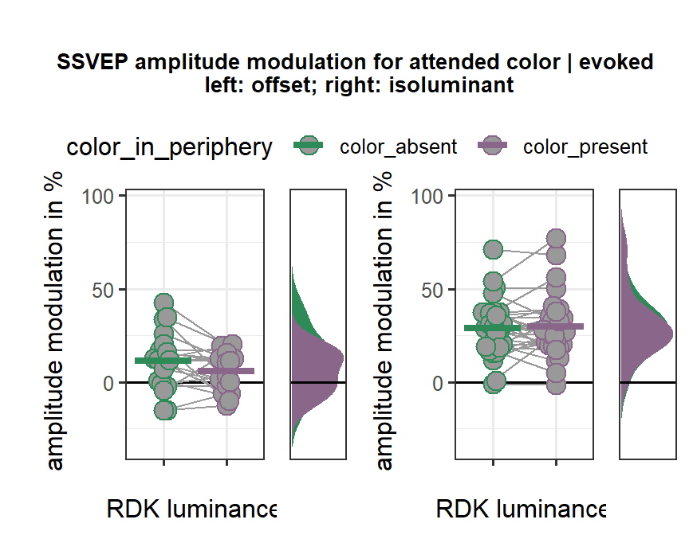

```r
dat2plot <- DataIn %>%
  filter(time == '[0.5 1.5] ') %>%
  group_by(subjects, condition) %>%
  mutate(
    color_in_periphery = case_when(
      RDK_id == "RDK1" &
        any(RDK_id == "RDK3" & RDK_ispresented == "presented") ~ "color_present",

      RDK_id == "RDK1" ~ "color_absent",

      RDK_id == "RDK2" &
        any(RDK_id == "RDK4" & RDK_ispresented == "presented") ~ "color_present",

      RDK_id == "RDK2" ~ "color_absent",

      TRUE ~ NA_character_
    )
  ) %>%
  ungroup() %>%
  # dplyr::select(-presented_RDK3, -presented_RDK4)%>%
  filter(RDK_position1=="center" & RDK_isattended =="attended")%>%
  group_by(subjects,RDK_colorlum, color_in_periphery)%>%
  summarise(modulation_evoked=mean(modulation_evoked))




# plot it
# set overall limits?
# set limits
yax_limits <- c( min(dat2plot$modulation_evoked), max(dat2plot$modulation_evoked))
yax_limits <- round(yax_limits + c(-1, 1)*diff(yax_limits)*0.1)
yax_limits <- yax_limits + c(-1, 1)*diff(yax_limits)*0.1




theme_set(theme_bw())
plot1 <- dat2plot %>%
  filter(RDK_colorlum=="offset_to_bckgrd")%>%
  ggplot(., aes(x = color_in_periphery, y = modulation_evoked, fill = color_in_periphery)) +
  geom_hline(yintercept=0, show.legend = FALSE) +
  geom_line(aes(group = interaction(subjects)),colour = "grey60",alpha = 1,size =0.5) +
  geom_beeswarm(aes(color = color_in_periphery, x = color_in_periphery,
                    group = color_in_periphery), cex=3, size = 4,alpha=1,fill="grey60",shape=21)+
  # geom_point(aes(color = RDK_isattended, x = interaction(time,RDK_isattended),
  #                   group = RDK_isattended), size = 4,alpha=0.4)+
  stat_summary(fun.y=mean, aes(ymin=..y.., ymax=..y.., color =color_in_periphery), geom='errorbar', width=0.9, size=1.5) +
  scale_x_discrete("RDK luminance", breaks=waiver(), labels = rep(c(""),1,2)) +
  # theme(legend.position="bottom") +
  ylab(expression(paste("amplitude modulation in %")))+
  scale_fill_manual(values=c("seagreen", "plum4"))+
  scale_color_manual(values=c("seagreen", "plum4"))+
  #  scale_fill_manual(values=c("#193A3D", "#F03F3F"))+
  # scale_color_manual(values=c("#193A3D", "#F03F3F"))+
  # scale_fill_manual(values=c(rgb2hex(0.0, 153.0, 204.0),rgb2hex(0.0, 77, 102.0)))+
  # scale_color_manual(values=c(rgb2hex(0.0, 153.0, 204.0),rgb2hex(0.0, 77, 102.0)))+
  theme(legend.position="none")+
  # scale_y_continuous(limits=c(-60, 140))
  scale_y_continuous(limits=yax_limits)


plot2 <- dat2plot %>%
  filter(RDK_colorlum=="offset_to_bckgrd")%>%
  ggplot(., aes(y = modulation_evoked, fill = color_in_periphery, x = 1)) +
  geom_flat_violin(aes(fill = color_in_periphery),position = position_nudge(x = .1, y = 0),
                   adjust = 1.3, trim = FALSE, alpha = 1, colour = NA)+
  geom_hline(yintercept=0, show.legend = FALSE) +
  # scale_fill_manual(values=c("#193A3D", "#F03F3F"))+
  # scale_color_manual(values=c("#193A3D", "#F03F3F"))+
  scale_fill_manual(values=c("seagreen", "plum4"))+
  scale_color_manual(values=c("seagreen", "plum4"))+
  # scale_fill_manual(values=c(rgb2hex(0.0, 153.0, 204.0),rgb2hex(0.0, 77, 102.0)))+
  # scale_color_manual(values=c(rgb2hex(0.0, 153.0, 204.0),rgb2hex(0.0, 77, 102.0)))+
  theme(axis.title.y=element_blank(),
        axis.text.y=element_blank(),
        axis.ticks.y=element_blank())+
  theme(axis.title.x=element_blank(),
        axis.text.x=element_blank(),
        axis.ticks.x=element_blank())+
  theme(panel.grid.major = element_blank(), panel.grid.minor = element_blank())+
  # scale_y_continuous(limits=c(-60, 140))
  scale_y_continuous(limits=yax_limits)


plot3 <- dat2plot %>%
  filter(RDK_colorlum!="offset_to_bckgrd")%>%
  ggplot(., aes(x = color_in_periphery, y = modulation_evoked, fill = color_in_periphery)) +
  geom_hline(yintercept=0, show.legend = FALSE) +
  geom_line(aes(group = interaction(subjects)),colour = "grey60",alpha = 1,size =0.5) +
  geom_beeswarm(aes(color = color_in_periphery, x = color_in_periphery,
                    group = color_in_periphery), cex=3, size = 4,alpha=1,fill="grey60",shape=21)+
  # geom_point(aes(color = RDK_isattended, x = interaction(time,RDK_isattended),
  #                   group = RDK_isattended), size = 4,alpha=0.4)+
  stat_summary(fun.y=mean, aes(ymin=..y.., ymax=..y.., color =color_in_periphery), geom='errorbar', width=0.9, size=1.5) +
  scale_x_discrete("RDK luminance", breaks=waiver(), labels = rep(c(""),1,2)) +
  # theme(legend.position="bottom") +
  ylab(expression(paste("amplitude modulation in %")))+
  scale_fill_manual(values=c("seagreen", "plum4"))+
  scale_color_manual(values=c("seagreen", "plum4"))+
  #  scale_fill_manual(values=c("#193A3D", "#F03F3F"))+
  # scale_color_manual(values=c("#193A3D", "#F03F3F"))+
  # scale_fill_manual(values=c(rgb2hex(0.0, 153.0, 204.0),rgb2hex(0.0, 77, 102.0)))+
  # scale_color_manual(values=c(rgb2hex(0.0, 153.0, 204.0),rgb2hex(0.0, 77, 102.0)))+
  theme(legend.position="none")+
  # scale_y_continuous(limits=c(-60, 140))
  scale_y_continuous(limits=yax_limits)


plot4 <- dat2plot %>%
  filter(RDK_colorlum!="offset_to_bckgrd")%>%
  ggplot(., aes(y = modulation_evoked, fill = color_in_periphery, x = 1)) +
  geom_flat_violin(aes(fill = color_in_periphery),position = position_nudge(x = .1, y = 0),
                   adjust = 1.3, trim = FALSE, alpha = 1, colour = NA)+
  geom_hline(yintercept=0, show.legend = FALSE) +
  # scale_fill_manual(values=c("#193A3D", "#F03F3F"))+
  # scale_color_manual(values=c("#193A3D", "#F03F3F"))+
  scale_fill_manual(values=c("seagreen", "plum4"))+
  scale_color_manual(values=c("seagreen", "plum4"))+
  # scale_fill_manual(values=c(rgb2hex(0.0, 153.0, 204.0),rgb2hex(0.0, 77, 102.0)))+
  # scale_color_manual(values=c(rgb2hex(0.0, 153.0, 204.0),rgb2hex(0.0, 77, 102.0)))+
  theme(axis.title.y=element_blank(),
        axis.text.y=element_blank(),
        axis.ticks.y=element_blank())+
  theme(axis.title.x=element_blank(),
        axis.text.x=element_blank(),
        axis.ticks.x=element_blank())+
  theme(panel.grid.major = element_blank(), panel.grid.minor = element_blank())+
  # scale_y_continuous(limits=c(-60, 140))
  scale_y_continuous(limits=yax_limits)



# cowplot::plot_grid(plot1, plot2, plot3, ncol = 3,labels = "AUTO")
plotttitle <- ggdraw() +
  draw_label("SSVEP amplitude modulation for attended color | evoked \nleft: offset; right: isoluminant",
             fontface='bold', size = 10)
plotplots <- ggarrange(plot1, plot2,plot3, plot4,ncol = 4,common.legend = TRUE,align = "h", widths=c(3,1,3,1))

savefig <- multi_panel_figure(columns = 1, rows = 1, panel_label_type = "none", width = 4.5, height = 3.5, unit = "in")
saveplot <- ggarrange(plotttitle, plotplots, nrow = 2, heights=c(0.2, 1))

savefig %<>%
  fill_panel(saveplot, column = 1, row = 1)
savefig
```

```r
# save_multi_panel_figure(savefig, "figures/FFT_BeeSwarm_Mod_ALPHA_COL_34subs.eps")


# statistical test
dat2plot %>%
  ungroup()%>%
  group_by(RDK_colorlum)%>%
  nest() %>%
    mutate(
    stats = map(data, ~ rstatix::t_test(modulation_evoked ~ color_in_periphery, data = ., paired = TRUE, detailed = TRUE)),
    t_test_bf = map(data, ~ extractBF(ttestBF(formula = modulation_evoked ~ color_in_periphery,
                                              data = ., iterations = num.iter, rscale = sqrt(2)/2))),
    meanval = map(data, ~ .x %>%
                    group_by(color_in_periphery) %>%
                    summarise(
                      mean_AMP_Mean = mean(modulation_evoked, na.rm = TRUE),
                      std_AMP_Mean = sd(modulation_evoked, na.rm = TRUE)
                    ) %>%
                    pivot_wider(names_from = color_in_periphery,
                                values_from = c(mean_AMP_Mean, std_AMP_Mean),
                                names_sep = "_")
    ),
    cohens_d = map(data, ~ rstatix::cohens_d(modulation_evoked ~ color_in_periphery, data = ., paired = FALSE))
  ) %>%
  unnest(cols = c(stats, t_test_bf, meanval))%>%
  mutate(CohensD = `statistic`/sqrt(df +1))%>%
  mutate(BF10 = bf, BF01 = 1/bf,
         M_AMP_abs = mean_AMP_Mean_color_absent,
         SD_AMP_abs = std_AMP_Mean_color_absent,
         M_AMP_pres = mean_AMP_Mean_color_present,
         SD_AMP_pres = std_AMP_Mean_color_present,
         diff=estimate,
         t.value=statistic,p.value=p)%>%
  dplyr::select(M_AMP_abs, SD_AMP_abs, M_AMP_pres, SD_AMP_pres, diff, t.value, df, p.value, CohensD, BF10, BF01)%>%
  mutate(
    p.value = cell_spec(ifelse(round(p.value,4)<.001,"< .001",round(p.value,4)),
                        color = ifelse(is.nan(p.value),"blue", ifelse(p.value < .05, "green", "red")),
                        bold = ifelse(is.nan(p.value),F, ifelse(p.value < .05, T,F)),
                        align = "center")
  ) %>%
  kbl(escape = F, digits = c(3,3,3,3,3,3,3,3,3), caption = c("central SSVEP | amplitude | pre-cue ")) %>%
  kable_styling("striped", full_width = T, bootstrap_options = c("striped", "hover", "condensed", "responsive",font_size = 8))
```

| RDK_colorlum | M_AMP_abs | SD_AMP_abs | M_AMP_pres | SD_AMP_pres | diff | t.value | df | p.value | CohensD | BF10 | BF01 |
| --- | --- | --- | --- | --- | --- | --- | --- | --- | --- | --- | --- |
| offset_to_bckgrd | 11.602 | 15.385 | 5.685 | 10.711 | 5.917 | 2.029 | 19 | 0.0567 | 0.454 | 0.676 | 1.479 |
| isolum__to_bckgrd | 29.051 | 15.057 | 29.610 | 16.772 | -0.559 | -0.261 | 29 | 0.796 | -0.048 | 0.264 | 3.782 |

#### analysis VI

**CENTRAL POST-CUE MOD** ~ **PRESENCE IN PERIPHERY**

Do we see differences in post-cue SSVEP modulations depending on whether the stimulus of the same color was present in the periphery?